# Meat lipids, NaCl and carnitine: Do they unveil the conundrum of the association between red and processed meat intake and cardiovascular diseases?_Invited Review - ScienceDirect

## Outline

1. Abstract
2. Keywords
3. Abbreviations
4. 1. Introduction
5. 2. Red and processed meat and CVD: epidemiological studies
6. 3. Underlying pathological mechanisms of red and processed meat consumption on CVD
7. 4. Concluding remarks
8. Declaration of Competing Interest
9. Acknowledgements
10. References

## Figures (3)

## Tables (1)

1. Table 1

## [Meat Science](https://www.sciencedirect.com/science/journal/03091740)

[Volume 171](https://www.sciencedirect.com/science/journal/03091740/171/supp/C), January 2021, 108278

# Review Meat lipids, NaCl and carnitine: Do they unveil the conundrum of the association between red and processed meat intake and cardiovascular diseases?_Invited Review

[JosuéDelgado<sup>a</sup>](https://www.sciencedirect.com/science/article/pii/S0309174020307105#!)[DianaAnsorena<sup>b</sup>](https://www.sciencedirect.com/science/article/pii/S0309174020307105#!)[ThomasVan Hecke<sup>c</sup>](https://www.sciencedirect.com/science/article/pii/S0309174020307105#!)[IciarAstiasarán<sup>b</sup>](https://www.sciencedirect.com/science/article/pii/S0309174020307105#!)[StefaanDe Smet<sup>c</sup>](https://www.sciencedirect.com/science/article/pii/S0309174020307105#!)[MarioEstévez<sup>d</sup>](https://www.sciencedirect.com/science/article/pii/S0309174020307105#!)

https://doi.org/10.1016/j.meatsci.2020.108278[Get rights and content](https://s100.copyright.com/AppDispatchServlet?publisherName=ELS&contentID=S0309174020307105&orderBeanReset=true)

## Abstract

The assessment of the actual contribution of red or processed meat to increasing the risk of suffering cardiovascular diseases (CVD) requires identification of specific harmful components and their underlying pathological mechanisms. In regards to CVD, meat lipids and their oxidation products have been recurrently studied due to their implications on lipid metabolism, hypercholesterolemia, obesity, and risk of suffering vascular events such as stroke. The impact of excess NaCl intake on increasing blood pressure is well-established and processed meat products have been recognized as a major contributor to dietary sodium in developed countries. Recent evidence has also suggested carnitine from red meat, as a precursor for trimethylamine-N-oxide, which has been shown to cause atherosclerosis, may increase the risk of suffering CVD in experimental animals. The present review aims to provide an updated overview, including evidence, controversies and unresolved questions on both the epidemiology and mechanisms relating red and processed meat consumption to CVD.

## Keywords

Saturated lipids

Cholesterol

Sodium

Carnitine

TMAO

Red meat

Processed meat

CVD

## Abbreviations

ACC

American College of Cardiology

AF

Atrial fibrillation

AHA

American Heart Association

BP

Blood pressure

CVD

Cardiovascular diseases

EFSA

European Food Safety Authority

eNOS

Nitric oxide synthase

FA

Fatty acids

HDL

High density lipoprotein

HHE

4-hydroxy-2-hexenal

HNE

4-hydroxy-2-nonenal

IHD

ischemic heart disease

LDL

Low-density lipoproteins

MDA

malondialdehyde

NLA

National Lipid Association

PUFA

polyunsaturated fatty acids

SFA

Saturated fatty acids

ROS

Reactive oxygen species

RR

Relative risk

SR

Salt-resistant

SS

Salt-sensitive

TMA

Trimethylamine

TMAO

Trimethylamine-N-oxide

T2D

Type II diabetes mellitus

UFA

Unsaturated fatty acids

WHO

World Health Organization

## 1. Introduction

Meat was first included in the diet by our human ancestors at least 3 million years ago (McPherron et al., 2010). The inclusion of meat in human diets played a key role in human evolution. It is highly unlikely that evolving humans could have achieved their unusually large and complex brain together with their evolutionary trajectory as large, active and highly social primates by eating solely vegetables (Milton, 2003). In fact, nowadays, red meat keeps playing an important role in the human diet, providing an important source of macro- and micronutrients. Meat is also highly appreciated by consumers for its sensory attributes and it is utterly tied to the gastronomy culture in many societies (Leroy & Cofnas, 2019). Red meat contains on average 20–24 g protein per 100 g fresh meat, being therefore considered a good source of high-quality protein. Red meat intake also provides other micronutrients, such as B vitamins, iron, zinc, phosphorous and magnesium (Wyness, 2016). Thus, red meat is generally accepted amongst nutritionists to be a valuable source of essential nutrients in a well-balanced diet.

However, over the last decade, several meta-analyses of observational epidemiological studies have associated high red meat and processed meat consumption with the onset of different health disorders (Abete, Romaguera, Vieira, Lopez de Munain, & Norat, 2014; Micha, Michas, & Mozaffarian, 2012; Yip, Lam, & Fielding, 2018). Amongst these pathological conditions, obesity and type II diabetes mellitus (T2D), colorectal cancer and cardiovascular disease (CVD) have attracted particular attention owing to their severity (as summarized by Rohrmann & Linseisen, 2016, Wolk, 2017 and Ekmekcioglu et al., 2018). It is worth emphasizing that red meat and processed meats should be differentiated when investigating their association with the aforementioned health disorders. According to the World Health Organization (World Health Organization, 2015), red meat refers to all mammalian muscle meat, including, beef, veal, pork, lamb, mutton, horse, and goat. This WHO definition of red meat is openly misleading since meat from certain domestic and wild birds (e.g. duck, ostrich, partridge…) is much redder than that of some of the aforementioned mammals. Yet, it is generally understood that myoglobin and heme iron are the primary determinants for the identification of red versus white meat. In regard to processed meat, the WHO states that such meat has been transformed through salting, curing, fermentation, smoking, or other processes to enhance flavor or improve preservation. Most processed meats contain pork or beef, but processed meats may also contain other red meats, poultry, offal, or meat by-products such as blood. It is also necessary to highlight that processed meats include a great variety of additives, such as NaCl, nitrites, phosphates, etc**.** Hence, the broad categorization and poor definition of meats and their processed derivatives used in nutritional epidemiology urges for a careful interpretation of the associations and does not allow to infer relative hazards for specific (processed) meats.

The studies establishing connections between consumption of red meat and/or processed meat and health disorders (see Section 2) have consequently led health authorities and associations such as the American College of Cardiology and American Heart Association, to recommend lowering the consumption of unprocessed red meat and processed meat to reduce cardiovascular risk and high blood pressure (BP) (Eckel et al., 2014; Whelton et al., 2018). Yet, a set of recent studies published in the *Annals of Internal Medicine* concluded that, overall, the evidence linking processed and unprocessed red meat consumption and cardiometabolic disorders and cancer, are of low certainty, and that the assumed health benefits of reduced red meat consumption lack a sound scientific basis (Johnston et al., 2019; Vernooij et al., 2019; Zeraatkar et al., 2019).

With implications that fresh red and processed meats are unhealthy, the application of strategies to achieve healthier meat products has been a hot topic in the field of meat science. Beyond epidemiological studies, the assessment of the actual contribution of particular fresh and processed meat components to increasing the risk of suffering health disorders, such as the abovementioned CVD, is essential. A detailed examination of the underlying pathological mechanisms of potential harmful components is required in order to design strategies for their mitigation if warranted. With regard to CVD, meat lipids have been recurrently studied due to their implications on lipid metabolism, hypercholesterolemia, obesity, and risk of suffering vascular events such as stroke (Nettleton, Brouwer, Geleijnse, & Hornstra, 2017). Owing to the effect of saturated fat intake on raising blood low-density lipoprotein (LDL)-cholesterol levels, and the observation that certain meats are relatively high in saturated fatty acids (SFA), producing and consuming leaner meats seemed reasonable in the past (Micha et al., 2012). However, this deduction negates the complex and variable fatty acid composition of meats, and the fact that the proportion of unsaturated fatty acids in most meat and meat products is higher than that of SFA (Wood et al., 2008). In addition, blood LDL levels seem to have a lower impact than its oxidized products (oxLDL) on CVD, since atherogenesis is initiated by oxidation of the lipids in LDL (Moss & Ramji, 2017). This mechanism, once initiated, is characterized by a positive feedback, in which oxLDL and the immune system play a crucial role (Buckley & Ramji, 2015; Ramji & Davies, 2015). Consequently, not only the total quantity of LDL, but also the oxidative balance should be monitored to assess the risk of suffering CVD. It is clear that this goes far beyond the SFA content of meats.

The epidemiological risk for CVD is more affected by the consumption of processed than by unprocessed meats (Ekmekcioglu et al., 2018; Micha et al., 2012). This has been suggested to be due to the content of sodium and other preservatives present in processed meat products (Micha et al., 2012). In fact, processed meats contain around 400% more sodium and 50 % more nitrates per gram than raw meat (Micha et al., 2012). The impact of NaCl on increasing BP is well-established, and processed meat products have been recognized as one major contributor to dietary sodium in developed countries. Additionally, nitrite concentrations in the blood have been correlated with endothelial dysfunction in humans (Rassaf et al., 2006), although recent studies have found prolonged dietary nitrate supplementation do not affect atherogenesis or exert other detrimental effects (Marsch et al., 2016). Indeed, dietary nitrate/nitrite is associated with better cardiovascular functioning in humans. In the mouth, nitrate is converted by bacteria to nitrite, which has vasodilating functions following absorption as nitric oxide (Borlaug, Koepp, & Melenovsky, 2015; Kapil et al., 2010).

Amongst the micronutrients found in red meat, carnitine may have cardioprotective effects through facilitating transport of long-chain fatty acids into the mitochondrial matrix or by reducing oxidative stress, inflammation and necrosis of cardiac myocytes (Wang, Liu, Liu, Lu, & Mao, 2018). However, recent studies have implied metabolites of ingested carnitine and choline are associated with the onset of CVD. In particular, trimethylamine N-oxide (TMAO) (Koeth et al., 2013), produced from carnitine or choline, has been shown to be associated with atherosclerosis (Schiattarella et al., 2017). The involvement of human gut bacteria in the formation of trimethylamine (TMA) in the gastrointestinal tract prior to its uptake into the bloodstream, and the rate and extent of its conversion to TMAO in the liver reflect the complexity involved in trying to understand the mechanism of action and underlying pathology. Thus, the gut microbiome plays an essential role in TMAO blood levels, which becomes a potential target to implement strategies in order to prevent TMAO accumulation in the blood.

The present review aims to provide an updated overview of the epidemiology and mechanisms in an effort to coalesce our current understanding of the effects of red and processed meat consumption on CVD with particular emphasis on meat lipids, NaCl and carnitine.

## 2. Red and processed meat and CVD: epidemiological studies

Numerous studies have been published on the association between meat consumption and various chronic diseases, summarized by Rohrmann and Linseisen (2016), Wolk (2017) and Ekmekcioglu et al. (2018). Studies on the epidemiological associations between red and processed meat consumption and cardiovascular diseases are listed in Table 1. Most studies basically differentiate between ‘red meat’, ‘processed meat’ and/or ‘white meat’; a distinction which by itself is vague and debatable (Demeyer, Mertens, De Smet, & Ulens, 2016; Keeton & Dikeman, 2017). Variation in the definitions of these terms and differing allocation of specific foods to these groups likely contribute to the heterogeneity in conclusions across studies, in addition to other factors such as residual confounding (Rohrmann & Linseisen, 2016). ‘Red meat’ usually refers to unprocessed beef, lamb and pork, ‘processed meat’ refers to any meat preserved by curing, salting or smoking, and ‘white meat’ includes meat from poultry.

Table 1. Overview of meta-analyses studying the epidemiological association between red meat (RM), processed meat (PM) and/or white meat (WM) consumption with the relative risk for cardiovascular disease (CVD), ischemic heart disease (IHD), total stroke, ischemic stroke and hemorrhagic stroke

|  | Studies | Cases (participants) | Relative risk (95% CI) | Unit | I<sup>2</sup> (%) |
| --- | --- | --- | --- | --- | --- |
| **CVD mortality** |  |  |  |  |  |
| (Pan et al., 2012) | 2 2 | 5 910 (121 342) 5 910 (121 342) | RM: 1.18 (1.13-1.23) PM: 1.21 (1.13-1.31) | serving/d serving/d | - - |
| (Abete et al., 2014) | 7 | 42 530 (1 615 868) | RM: 1.16 (1.03-1.32) | H vs. L | 82.5** |
|  | 6 | 35 537 (1 186 761) | PM: 1.18 (1.05-1.32) | H vs. L | 73.7** |
|  | 6 | 36 620 (1 494 526) | WM: ns | H vs. L | 10.6 |
| (Wang et al., 2016) | 6 | 22 222 (947 015) | RM: ns | H vs. L | 84.5** |
|  | 6 | 33 278 (1 195 947) | PM: 1.15 (1.07-1.24) | serving/d | 75.4** |
| **IHD incidence** |  |  |  |  |  |
| (Micha et al., 2012) | 4 | 769 (56 311) | RM: ns | 100 g/d | - |
|  | 5 | 21 308 (614 062) | PM: 1.42 (1.07-1.89) | 50 g/d | - |
| **IHD mortality** |  |  |  |  |  |
| (Abete et al., 2014) | 3 | 716 (64 109) | PM: ns | H vs. L | 81.7** |
|  | 4 | >928* (230 693) | RM: ns | H vs. L | 70.3** |
|  | 3 | 928 (196 495) | WM: ns | H vs. L | 0 |
| **Total stroke** |  |  |  |  |  |
| (Kaluza et al., 2012) | 5 4 | 10 630 (329 495) 9 581 (242 470) | RM: 1.11 (1.03-1.20) PM: 1.13 (1.03-1.24) | serving/d serving/d | 0 37.8 |
| (Chen et al., 2013) | 4 4 | 9 593 (239 251) 9 593 (239 251) | RM: 1.09 (1.01-1.18) PM: 1.14 (1.05-1.25) | H vs. L H vs. L | 0 23 |
| (Yang et al., 2016) | 4 4 | 9 581 (242 470) 9 581 (242 470) | RM: 1.13 (1.04-1.22) PM: 1.17 (1.09-1.27) | H vs. L H vs. L | 0 0 |
| (Kim et al., 2017) | 5 5 2 | 9 522 (254 742) 9 522 (254 742) 4 759 (138 761) | RM: 1.11 (1.03-1.20) PM: 1.17 (1.08-1.25) WM: 0.87 (0.78-0.97) | H vs. L H vs. L H vs. L | 0 0 0 |
| **Ischemic stroke** |  |  |  |  |  |
| (Kaluza et al., 2012) | 4 4 | 6 420 (289 146) 5 371 (202 121) | RM: 1.13 (1.00-1.27) PM: 1.15 (1.06-1.24) | serving/d serving/d | - - |
| (Chen et al., 2013) | 3 3 | 5 371 (202 121) 5 371 (202 121) | RM: 1.13 (1.01-1.25) PM: 1.19 (1.08-1.31) | H vs. L H vs. L | - - |
| (Yang et al., 2016) | 4 1 | 4 220 (1 979 276) 2 212 (127 160) | RM: 1.15 (1.03-1.29) PM: ns | H vs. L H vs. L | 0 27.6 |
| (Kim et al., 2017) | - - | - - | RM: 1.24 (1.05–1.46) PM: ns | H vs. L H vs. L | 17.7 11.7 |
| **Hemorrhagic stroke** |  |  |  |  |  |
| (Kaluza et al., 2012) | 4 | 1 276 (289 146) | RM and PM: ns | serving/d | - |
| (Chen et al., 2013) | 3 | 1 276 (202 121) | RM and PM: ns | H vs. L | - |
| (Yang et al., 2016) | 5 | 1 931 (1 391 196) | RM ns | H vs. L | 43.7 |
|  | 3 | 1 276 (202 121) | PM: ns | H vs. L | 18.6 |
| (Kim et al., 2017) | - | - | RM and PM: ns | H vs. L | 0/8.1 |

* One of the studies does not specify the amount of cases; H vs. L= highest vs lowest quintile of intake. RM= red meat; PM= processed meat; WM=white meat: CVD= cardiovascular disease; IHD=ischemic heart disease. ** = P-value < 0.05

Three meta-analyses were found summarizing the observational epidemiological studies on red meat, and processed meat consumption and all-case-mortality related to CVD (Abete et al., 2014; Pan et al., 2012; Wang et al., 2016). All studies reported a significantly increased relative risk (RR) for CVD mortality, ranging between 15 and 21% for each serving of processed meat per day, or when the highest quintile of consumption was compared to the lowest. Nevertheless, a high heterogeneity (I<sup>2</sup> not reported, or circa 75%) was observed in the analyses. The RR for red meat consumption with CVD mortality was either not significant (Wang et al., 2016), or significant (Abete et al., 2014; Pan et al., 2012), with unreported or high (I<sup>2</sup>>82.5%) heterogeneity. White meat consumption was not associated with CVD mortality, with very low heterogeneity in the analyses (I<sup>2</sup>=10.6) (Abete et al., 2014).

In summary, available meta-analyses show negative or no association between white meat consumption and CVD, whereas red and/or processed meat consumption seems to be associated with a higher RR for CVD all-cases-mortality, IHD incidence, total stroke, and/or ischemic stroke. Reported RR varied from 9 to 42% when comparing high vs. low consumption, or per serving per day, and a large heterogeneity was observed in meta-analyses on CVD and IHD mortality. These modest RR values may not be meaningful at the individual level, however, may have implications at the population level and be relevant from a public health perspective. For example*,* high processed meat consumption was estimated to contribute to 8.2% of cardiometabolic deaths in the USA, compared to 9.5% due to high sodium intake, and 7.4% due to high consumption of sugar-sweetened beverages (Micha et al., 2017). In contrast, a series of recent studies published in the *Annals of Internal Medicine* stated that the evidence of these mentioned associations is of low certainty, based on the application of the GRADE tool (Vernooij et al., 2019; Zeraatkar et al., 2019; Zeraatkar, Han, et al., 2019). The question remains if GRADE, originally designed to rate clinical drug trials, should be applied to public health epidemiological studies, since observational data start this evidence weighting process with a rating of ‘low evidence’ and may be further downgraded to ‘very low’ (Neuhouser, 2020).

## 3. Underlying pathological mechanisms of red and processed meat consumption on CVD

### 3.1. Lipids

The lipid fraction of meat, particularly some species, is characterized by relatively high amounts of SFA and cholesterol, whose dietary intake has been traditionally associated to a higher risk of CVD. Furthermore, polyunsaturated fatty acids (PUFA) in meat are sensitive to oxidation, which may also contribute to CVD risk. An evaluation of the mechanisms underlying these statements is presented in this section.

#### 3.1.1. Cholesterol

The cholesterol content of meat depends on species, type of product and cooking treatment, and is approximately 50-100 mg/100g fresh meat (Dinh, Thompson, Galyean, Patterson, & Boylan, 2011). The mean cholesterol intake in US adults in 2013-2014 was estimated at 290 mg/day and has remained unchanged over the past 10 years, with contribution of meat and meat products estimated to be approximately 42% (Xu, McClure, & Appel, 2018).

Lifelong exposure to elevated LDL cholesterol blood levels has been confirmed to be a cause of atherosclerotic cardiovascular disease (Gidding & Allen, 2019), an inflammatory disorder of the arterial wall. In fact, atherogenic lipoproteins have the ability to infiltrate the arterial wall and to bind extracellular molecules (Gidding & Allen, 2019). Then, they become trapped and are modified through oxidation, increasing their inflammatory properties and contributing to form a fibrous plaque, which can cause stenosis and tissue ischemia (Figure 1). Moreover, when plaque rupture occurs, subendothelial components are exposed to the blood, leading to luminal thrombosis, which can potentially give rise to occlude arterial flow (Jacobson et al., 2015). A recent meta-regression analysis that used data from randomized dietary intervention trials pointed out that, after adjustment for dietary fatty acids, changes in dietary cholesterol were positively associated with changes in blood LDL-cholesterol concentration (Vincent, Allen, Palacios, Haber, & Maki, 2019).

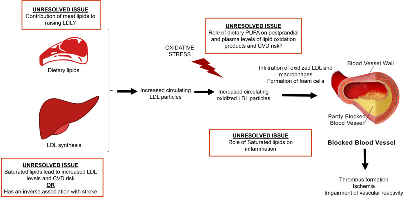

Fig. 1. Underlying mechanisms of the pathophysiological effects of dietary lipids on CVD.

However, it is nowadays questioned whether high LDL cholesterol levels are responsive to high intakes of cholesterol, and thus, it is under debate whether dietary cholesterol is associated to CVD. It has been reported that dietary cholesterol accounts for approximately 5 % higher serum cholesterol levels as compared to fasting conditions (Berger, Raman, Vishwanathan, Jacques, & Johnson, 2015; Grundy, 2016). Grundy (2016) also reported that different mechanisms protect against marked hypercholesterolemia with the suppression of cholesterol synthesis and an enhanced conversion of cholesterol into bile acids being among them. Furthermore, according to the American Heart Association (AHA) and the American College of Cardiology (ACC) there is insufficient evidence to advise reducing dietary cholesterol for lowering LDL-cholesterol (Eckel et al., 2014). In addition, to date, extensive research in population studies did not show evidence to support a role of dietary cholesterol in the development of CVD (Soliman, 2018). In its report “Dietary reference values for fats”, the European Food Safety Authority (EFSA) concludes that, at current levels of intake, available data on the relationship between cholesterol intake and cardiovascular disease are inconsistent (EFSA, 2010), so no particular restriction of dietary cholesterol is suggested by this health authority. Similarly, the recommendation from the 2010 Dietary Guidelines to limit consumption of dietary cholesterol to 300 mg per day is no longer included in the 2015 edition (HHS & USDA, 2015). On the contrary, the National Lipid Association (NLA) recommends <7% of calories from saturated fat and <200 mg/day of dietary cholesterol (Jacobson et al., 2015).

Discrepancies about the role of dietary cholesterol on CVD might be linked to the fact that most foods with high cholesterol content are also rich in SFA, a known determinant of serum cholesterol levels (Soliman, 2018). Thus, further research that controls for saturated fat intake is required to conclude about the contribution of dietary cholesterol to lipid/lipoprotein levels and CVD risk (Bowen, Sullivan, Kris-Etherton, & Petersen, 2018).

#### 3.1.2. SFA

There is a long-held perception that meat consumption greatly contributes to total SFA intake. SFA account for approximately 30 to 45% of total fatty acids in intramuscular or subcutaneous fat depots, depending on several factors such as type of fat depot, species, and, above all, the animals’ feeding background (Raes, De Smet, & Demeyer, 2004; Wood et al., 2008). Ruminants’ fat depots are generally more saturated compared to monogastric animals due to the rumen biohydrogenation process. This is accompanied by the deposition of a broad spectrum of biohydrogenation intermediates, with some of them displaying beneficial health properties (e.g. conjugated linoleic acid or vaccenic acid) (Dugan, Aldai, Aalhus, Rolland, & Kramer, 2011), which may be isomer specific. In addition, and even more important, it should be realized that the total fat content of many fresh meats is lower than 5%, hence only contributing modestly to total fat and SFA intake. Indeed, in a cross-European study, the contribution of total meat and meat products intake to total SFA and total *trans* fatty acids intake varied among countries between 14 and 29% and between 5 and 30% respectively (Hulshof et al., 1999). These figures are hard to reconcile with a supposed effect of red meat consumption on CVD owing to the dietary contribution of such meat in terms of SFA and *trans* fatty acids.

During the last decades, an association between a high SFA intake and an increased risk of CVD was generally accepted, explained by the stimulating effects of dietary SFA intake on blood lipoprotein-cholesterol levels (Willett, 2012). However, an increasing number of studies point out certain controversy about this association (Hoenselaar, 2012; Kuipers, De Graaf, Luxwolda, Muskiet, & Muskiet, 2011; Ruiz-Núñez, Dijck-Brouwer, & Muskiet, 2016; Siri-Tarino, Sun, Hu, & Krauss, 2010; Yongjian Zhu, Bo, & Liu, 2019). In fact, the prospective cohort PURE study (Dehghan et al., 2017), compiling epidemiological data from 18 countries, reported an inverse association between SFA intake and stroke risk and no association between total fat and individual types of fat, and cardiovascular disease, myocardial infarction or cardiovascular disease mortality. Yet, a positive association between total fat and SFA with blood pressure was reported (Mente et al., 2017). However, the latter study also mentioned that replacing SFA with carbohydrates had adverse effects on blood lipids, whereas replacement of SFA with unsaturated fatty acids (UFA) decreased LDL and blood pressure, but also decreased high density lipoprotein (HDL). Indeed, Ruiz-Núñez et al. (2016) reviewed that the influence of SFA on CVD risk depends on the total energy, the balance between omega-3 and omega-6 PUFA and the amounts of carbohydrates in the diet, next to many other lifestyle factors. Moreover, assorted studies show that not all SFA exert physiological effects alike, and actually, it is known that their effects on CVD diseases are diverse. Stearic acid (18:0) consumption is known to not be deleterious because it can be converted to oleic acid (18:1) (Hunter, Zhang, Kris-Etherton, & Childs, 2010). Higher levels of circulating 18:0, 20:0, 22:0, and 24:0 were each also associated with a lower risk of atrial fibrillation (AF), while palmitic acid (16:0) increased the risk (Fretts et al., 2014). Moreover, no correlation has been found between SFA intake and the SFA status (amount in the organism) (Forsythe et al., 2008; Volek, Fernandez, Feinman, & Phinney, 2008). In addition, the intake of SFA not only raises LDL-cholesterol, but also raises the beneficial HDL-cholesterol, with HDL-raising effects being greater as the SFA chain-length decreases (Micha & Mozaffarian, 2010).

In addition to the effect of SFA intake on blood lipoprotein levels, the consumption of SFA may also affect cardiovascular health through other mechanisms including inflammation. Due to the limited number of intervention studies involving meat and/or meat products to explain some of the potential mechanisms participating in this connection, studies with other SFA sources are described here as well, to elaborate on this hypothesis. The consumption of SFA (coconut oil) vs. PUFA (safflower oil) impaired the ability of HDL to inhibit the expression of pro-inflammatory adhesion molecules (ICAM-1 and VCAM-1) by endothelial cells, and also caused an impairment of vascular reactivity (Nicholls et al., 2006). The latter study may however have been confounded by the strongly contrasting vitamin E contents of the fat sources used (Masterjohn, 2007). In contrast, no changes were observed in ICAM and VCAM in blood of volunteers with moderate CVD risk, following the substitution of circa 10% total energy dietary SFA (butter) with either MUFA (olive oil, rapeseed oil) or n-6 PUFA (safflower oil) (Vafeiadou et al., 2015). However, this substitution improved the blood lipoprotein profile, and decreased circulating endothelial and platelet microparticle numbers, suggesting beneficial effects on endothelial repair and maintenance (Weech et al., 2018). Consumption of meat enriched with walnuts (source of PUFA and other nutrients) vs. lean meat lowered the levels of ICAM and VCAM, but also of leukotriene B4 in blood of humans at increased cardiovascular risk (Canales et al., 2011). However, the effects of meat consumption on inflammation are not well described and often conflicting, likely not only explained by differences in their fatty acid profile, but also in the sensitivity of the meat to form PUFA-derived oxidation products or other potentially harmful metabolites during processing and gastrointestinal digestion (Van Hecke, Van Camp, & De Smet, 2017). Indeed, oxidative stress is closely interrelated with vascular inflammation, endothelial dysfunction and vascular damage (Siti, Kamisah, & Kamsiah, 2015). Recent research by Joseph et al. (2019) showed that the intake of SFA (palm oil) by mice, can also increase oxidative stress in cardiomyocytes by activating NOX2, resulting in abnormalities of calcium homeostasis and heart rhythm, before the onset of obesity.

During the last two decades, many studies have been conducted to ‘improve’ the fatty acid profile of fresh meat and meat products, either by modifying animal diets or by adding PUFA rich fat sources during meat processing (Alejandre, Astiasarán, & Ansorena, 2019; Ansorena & Astiasarán, 2014; De Smet & Vossen, 2016; Dugan et al., 2011). Most of these studies focused on enhancing the PUFA content, thereby indirectly lowering the SFA content, and on lowering the n-6/n-3 FUFA ratio. Several of these approaches have been implemented in commercial practice, meaning that there are nowadays omega-3 enriched meat products in the market and that there is more variation in meat fatty acid composition than generally anticipated. Unfortunately, few intervention studies have investigated the impact of their consumption on cardiovascular health. It was reviewed that enrichment of meat with alpha-linolenic acid generally does not affect blood lipoproteins upon consumption in humans, whereas some positive effects were reported with consumption of meats enriched with long chain n-3 PUFA (De Smet & Vossen, 2016). In more recent studies, beef fat enriched with PUFA biohydrogenation products improved insulin sensitivity in insulin resistant rats (Diane et al., 2016). Similarly, it has been reported that the daily intake of broth from meat of linseed-fed cattle had a positive had a positive effect on insulin sensitivity in healthy human volunteers (Bacs et al., 2019). Further human intervention studies are definitely needed to properly assess the effect of meat fatty acid composition on human health and the risk of chronic diseases. Taking into account all this information, it is clear that the presumed effects of meat and meat product consumption on risk of CVD cannot be simply deduced to be due to the SFA content. Further investigations on effects of the complete fatty acid profile of meat and meat products are needed in order to establish their roles in the development of CVD.

#### 3.1.3. Oxidized lipids

In addition to the role of LDL cholesterol in atherogenesis, the role of oxidized lipoproteins in the etiology of vascular impairment has also been widely demonstrated (Ahotupa, 2017). In fact, certain type of lipids such as PUFA-containing phospholipids and cholesterol esters are easily oxidized under oxidative stress, forming a complex mixture of oxidation products, which are actively involved in the inflammatory responses in atherosclerosis by interacting with immune cells and endothelial cells (Testa, Rossin, Poli, Biasi, & Leonarduzzi, 2018; Zhong et al., 2019). Oxidized lipids can be formed endogenously, but they can also be ingested from the diet due to lipid oxidation in foods caused by heat treatments, contact with oxygen, exposure to sunlight, etc. (Otaegui-Arrazola, Menéndez-Carreño, Ansorena, & Astiasarán, 2010). In direct evidence, it has been reported when rabbits were fed oxidized fatty acids or oxidized cholesterol, the fatty streak lesions in the aorta were increased by 100% (Staprans, Pan, Rapp, & Feingold, 2005). These authors also showed that oxidized dietary cholesterol significantly increased aortic lesions in apo-E and LDL receptor-deficient mice.

Lipid oxidation also occurs during the passage of meat through the different compartments of the gastrointestinal system, and is promoted by the presence of heme iron, higher levels of PUFA, and the absence of suitable antioxidants (Van Hecke, Van Camp, & De Smet, 2017). The oxidation of n-6 PUFA and n-3 PUFA lead to the specific formation of 4-hydroxy-2-nonenal (HNE) and 4-hydroxy-2-hexenal (HHE) respectively, whereas malondialdehyde (MDA) can originate from both PUFA sources. These lipid oxidation products have a varying toxic potential, and can be absorbed into the blood and in turn can cause LDL modification (Kanner, Gorelik, Roman, & Kohen, 2012). Included with various other proatherogenic mechanisms, HNE can induce dysfunction of endothelial nitric oxide synthase (eNOS), whereby it reduces the formation of vasodilating nitric oxide, and increases blood pressure (Nègre-Salvayre & Salvayre, 2018). Consequently, minimizing the oxidation of lipids during meat storage and processing, and during gastrointestinal digestion might contribute to a decreased risk of CVD. Indeed, Gorelik, Kanner, Schurr, and Kohen (2013) demonstrated in a human intervention study that an increase in blood MDA-LDL following the consumption of turkey meat can be completely prevented by the simultaneous ingestion of red wine polyphenols. The addition of phenolic-rich spices and herbs during meat processing (Van Hecke, Ho, Goethals, & De Smet, 2017), or curing with nitrite salt (Van Hecke et al., 2014) can almost completely prevent lipid oxidative damage during gastrointestinal digestion of meat. Also, the use of fiber with antioxidant properties in meat-based products has been shown to delay lipid oxidation during storage (Das, Nanda, Madane, Zhang, & Lorenzo, 2020). However, the high salt content in cured meat may promote CVD by other mechanisms, as further described. Also, since a large formation of n-3 PUFA oxidation products occurs during the digestion of fish compared to meat (Steppeler, Haugen, Rødbotten, & Kirkhus, 2016; Van Hecke, Goethals, Vossen, & De Smet, 2019), and fish consumption is generally considered as beneficial for cardiovascular health, question remains to what extent these lipid oxidation products are involved in development of CVD.

### 3.2. NaCl

Sodium is an essential nutrient, being necessary for neurotransmission and normal cell homeostasis. Most sodium in the human diet is associated with chloride, as NaCl. The minimum physiological requirement for this element is estimated to be 200-500 mg/day (about 0.5-1.25 g of NaCl/day), whilst the average amount of sodium considered as adequate is around 1.5 g/day (3.8 g NaCl/day). The recommended sodium consumption for adults, which is 2 g sodium/day (equivalent to 5 g salt/day), is exceeded by consumers in many countries (World Health Organization, 2012). These recommendations and limitations arise from the fact that NaCl does have a deep impact on consumer’s health, as will be argued later. It is noteworthy, however, to highlight that NaCl might have a more important role in salt-sensitive hypertension than sodium intake than from other sources such as sodium bicarbonate (Mohammadifard et al., 2018)

At this point we must discriminate between the NaCl intake from meat and processed meat products. Whilst the NaCl quantity in the former is negligible, the latter have been recognized as a major contributor to dietary sodium in developed countries, mainly due to the content of sodium and other preservatives present in these processed products. In fact, processed meats contain around 400 % more sodium and 50 % more nitrates per gram than fresh meats (Micha et al., 2012). In general, in European countries, meat products are the second highest contributors to NaCl intake (19%), whereas bakery products and cereals contribute 36% (Kloss, Meyer, Graeve, & Vetter, 2015; Marrero, He, Whincup, & MacGregor, 2014). Interestingly, the two countries within the EU where meat products have the highest impact on total NaCl intake are Spain and Norway. Similarly, in the United States, processed meat products are the second contributor to dietary sodium intake, after bakery products (Centers for Disease Control and Prevention, 2011).

NaCl plays a key role in meat products, particularly in dry-cured products. The added salt enhances protein solubility, dehydrates the product and contributes to microbial stability through water activity reduction. Additionally, NaCl is a powerful flavoring, which makes it extremely difficult to reduce its quantity without losing the desired sensory properties. However, as stated previously, the average NaCl intake is beyond the general recommendations in many countries, which has a clear negative impact on health. Strazzullo, D’Elia, Kandala, and Cappuccio (2009) report strong relationships and links between sodium intake, hypertension and CVD based on analysis of prospective studies. It has been estimated that 90% of heart failure hospitalizations in the United States and Europe are due to symptoms and signs of sodium and fluid excess (Costanzo & Jessup, 2012). Additionally, there were around 1.65 million deaths worldwide in 2010, associated with increased BP and CVD caused by high sodium intake. These deaths represented about 1 out of 10 deaths due to CVD, and 2 out of 5 deaths were premature (before 70 years of age) (Mozaffarian et al., 2014). In line, Micha et al. (2017) estimated the largest proportion of all cardiometabolic deaths (9.5%) were related to high sodium intake in comparison 8.2% to high processed meat, and 7.4% to sugar sweetened beverages.

The physiological mechanisms underlying BP are not fully elucidated, but, in general, alterations in renal function, hormones involved in fluid excretion/retention, the vasculature, the heart, and/or central sympathetic outflow are involved (Farquhar, Edwards, Jurkovitz, & Weintraub, 2015). Endothelial function is reduced in arteries by sodium loading in normotensive men, whilst the restriction of this element in hypertensive patients provokes an improvement in endothelial function (Jablonski et al., 2013; Tzemos, Lim, Wong, Struthers, & MacDonald, 2008). The deleterious effect of sodium on endothelial function has been linked to reactive oxygen species (ROS) increment, particularly of superoxide, which in turn decreases the vasodilator effects of nitric oxide in endothelium (Nurkiewicz & Boegehold, 2007). High levels of sodium have been also found to stiffen the arteries through ROS and endothelium sodium channels which provoke a reduction in the elastin/collagen ratio (Salvi, Giannattasio, & Parati, 2018). The heart is the main organ suffering the consequences of increased BP in the long term, with left ventricular hypertrophy as the most common pathology (Farquhar et al., 2015). Figure 2 illustrates the harmful effect of excess NaCl intake on vascular function.

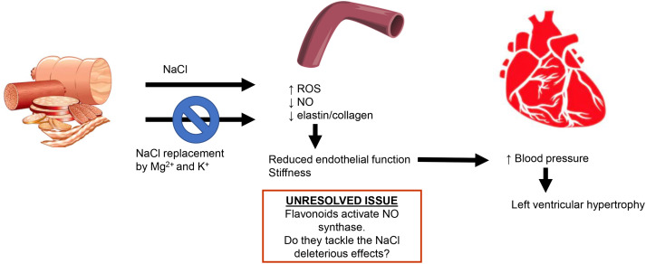

Fig. 2. Underlying mechanisms of the pathophysiological effects of NaCl on CVD.

One of the main problems that needs to be addressed is the difference in sensitivity of BP to alterations in dietary sodium, leading to the concept of salt-sensitive (SS) and salt-resistant (SR) individuals, which has been known about for many years (Weinberger, 1996). The former group comprises aged, hypertensive, chronic kidney disease-suffering or low birth weight people, whilst the latter includes young, middle-aged and normotensive people (Farquhar et al., 2015). Additionally, the use of nonsteroidal anti-inflammatory drugs (e.g. ibuprofen) increases BP, via prostaglandin synthesis inhibition which leads to renal and systemic vasoconstriction that in turns increases sodium and water retention. The high sodium intake in combination with this kind of drugs is of utmost relevance, especially for older people, who routinely take it for chronic pain. This fact could increase the incidence of heart failure (Chrysant, 2016). Then, the general nutritional recommendations are only applicable to the normotensive population, and several criteria have to be considered to develop recommendations for particular groups.

In general terms, it is accepted that dietary sodium reduction towards the WHO guidelines leads to a significant reduction in BP and cardiovascular disease risk (Choi, Brandeau, & Basu, 2016; Nghiem, Blakely, Cobiac, Pearson, & Wilson, 2015). Particularly, a linear association between salt restriction and systolic BP has been shown, as well as a reduction of sodium intake lowers arterial stiffness in hypertensive patients (Farquhar et al., 2015). Thus, strategies are required for limiting the sodium content in foods, especially in processed meat products as one of the highest contributors of salt to the diet.

Given the key role played by NaCl in processed meats, the reduction in NaCl is limited by the desired physicochemical properties to achieve product, flavor and microbial stability. Thus, the most extensive strategy followed has been replacing this salt by others containing potassium, calcium, and/or magnesium instead of sodium. This strategy has been proven to be effective to reduce BP (Sarkkinen et al., 2011). The use of these salts requires optimization of the processes to achieve the desired sensory properties of the final product (Allison & Fouladkhah, 2018). These salts also partially modify the taste of the product, particularly, bitterness is the most common flavor detected in these products (Armenteros, Aristoy, Barat, & Toldrá, 2012). On the other hand, the impact of sodium intake through unprocessed meat products is greatly limited due to the low natural levels (Micha et al., 2012). The sodium intake from fresh meats will depend on the amount of salt added at the table based on consumer preference (Brown, Tzoulaki, Candeias, & Elliott, 2009).

It is a worthy strategy to reduce the sodium content in meat products. However, combining strategies to minimize the pathophysiological mechanisms of dietary salt may also be required. High ROS generation provokes oxidative stress. This phenomenon lowers nitric oxide synthesis, which in turn reduces vasodilatation, increasing BP. Then, new strategies based on balancing these effects are required. As an example, flavonoid-rich beverages consumption has been associated with a reduction in coronary events, particularly, flavanol-rich cocoa has been found to activate nitric oxide synthase, providing a plausible mechanism for the protection that flavanol-rich foods induce against coronary events (Fisher, Hughes, Gerhard-Herman, & Hollenberg, 2003). Therefore, antioxidants included as ingredients in meat products may contribute to tackle the cited deleterious effects. The combination of the inclusion of these compounds in meat products with NaCl reduction/replacement may help to mitigate the detrimental effects of sodium intake from processed meats related with CVD.

### 3.3. Carnitine

L-carnitine, commonly refered to as carnitine, is a natural and biologically active amino acid derivative, which transports activated long chain fatty acids from the cytosol into mitochondria for subsequent β-oxidation, and supports other physiological activities (Knüttel-Gustavsen & Harmeyer, 2011; Wang et al., 2018). Carnitine is not considered an essential nutrient (Vaz & Wanders, 1982), although it might be regarded as a conditionally essential nutrient during certain physiological conditions.

Carnitine enters the body through animal-derived food intake as milk-based or meat products. The concentration of this nutrient varies greatly amongst different animal-derived foods with meat-based products containing much higher carnitine concentrations than milk-based products. With regard to the meat carnitine content, raw meat from beef contains *c.a.* 70 mg/100g, chicken 10 mg/100g, turkey 21 mg/100g, duck 27 mg/100g, lamb 40 mg/100g and pork 30 mg/100g (Demarquoy et al., 2004). However, depending on the cooking process that the meat underwent, the carnitine content can drop up to 50% (Knüttel-Gustavsen & Harmeyer, 2011). Thus, the cooking process seems to substantially alter the content of this nutrient, which is of utmost interest in order to calculate carnitine intake.

For many years, carnitine has been known to have antioxidant effects and has been demonstrated to exert beneficial effects on plasma proteins by inhibiting peroxidation induced by peroxynitrites through direct scavenging of free radicals (Reznick et al., 1992). Carnitine has also been shown to chelate catalytic metals-promoters of ROS, and inhibit ROS-generating enzymes. It also affects redox-signaling via activation of Nrf2, PPARα and inhibits NF-κB by enhancing the synthesis of antioxidant enzymes (Kolodziejczyk, Saluk-Juszczak, & Wachowicz, 2011; Reznick et al., 1992; Yang, Yang, & Cao, 2015). These physiological effects may lead to a beneficial impact on CVD through reductions in stress-induced hypertension, diabetic ketoacidosis, hyperosmolar hyperglycemia, insulin-dependent diabetes mellitus, insulin resistance and obesity (Wang et al., 2018). Considering these biological activities, carnitine has successfully been used at supra-nutritional doses as a supplement for treating CVD (DiNicolantonio, Lavie, Fares, Menezes, & O’Keefe, 2013). Researchers have calculated a 40% reduction in anginal symptoms in patients experiencing an acute myocardial infarction with carnitine supplementation compared to placebo controls.

Nevertheless, over the last decade any positive aspect about carnitine intake has been brought into question because it is a precursor of TMAO, a metabolite suggested to be involved in atherogenesis (Koeth et al., 2013). Briefly, TMA is produced from choline and carnitine by various taxa present in the gut microbiota. TMA is then absorbed via the intestinal epithelium and metabolized to TMAO in the liver (Rath, Heidrich, Pieper, & Vital, 2017).

The carnitine oxygenase (cntA) enzyme is essential for gut microbial transformation of carnitine into TMA. CntA belongs to a group of previously uncharacterized Rieske-type proteins, and has an unusual “bridging” glutamate but not the aspartate residue. The taxa endowed with cntA are *Gamma-* and *Betaproteobacteria,* as well as a few from *Firmicutes*. Additionally, *Acinetobacter baumannii* and *Escherichia coli* have been functionally proven to require this protein for TMA formation (Rath et al., 2017; Zhu et al., 2014). Nonetheless, a recent study points out that cntA is not a good biomarker for identifying TMAO producers, and there might be other potential microbial genes responsible for carnitine metabolism to TMA in gut microbiota (Wu et al., 2018). Given the complexity of the gut microbiota composition, it can be inferred that further studies are required to decipher the microorganisms and their biochemical mechanisms involved in TMA formation. Finally, once TMA is produced by microorganisms, it is further oxidized to TMAO by flavin monooxygenases in the liver (Koeth et al., 2013).

Numerous studies indicate that TMAO is associated with atherosclerosis, and there is a positive dose-dependent association between TMAO plasma levels and increased cardiovascular risk as well as mortality (Koeth et al., 2013; Schiattarella et al., 2017). There are several pathological mechanisms explaining the effect of TMAO on health.

Cholesterol transport has been proven to be negatively influenced by this metabolite, because of the suppression of reverse cholesterol transport (Koeth et al., 2013). TMAO also promotes vascular inflammation and increases platelet reactivity along with associated augmentation of thrombotic event risk, meaning higher risk of myocardial infarction and stroke (Seldin et al., 2016; Zhu et al., 2016). On the other hand, some criticism can be found regarding the causal link between TMAO and CVD, since fish and seafood contain considerable amounts of free TMAO, which is in contrast with the generally accepted cardioprotective properties of fish consumption (Landfald, Valeur, Berstad, & Raa, 2017). Specifically, fish intake by healthy humans resulted in 46-62 times higher circulating and urinary TMAO levels compared to the intake of eggs or beef (Cho et al., 2017), which raises doubts on the relevance of carnitine intake from meat on CVD through the formation of TMAO. This finding suggests that TMAO alone, may not explain the epidemiological link between red meat consumption and CVD, and mechanisms are probably more complicated. Along this line, some studies suggested that TMAO may be a biomarker for impaired kidney function and poor metabolic control rather than having a causative role on CVD (Mueller et al., 2015), or may reflect a specific colon microbial composition associated with CVD (Cho et al., 2017). It was recently also hypothesized that increased plasma TMAO would serve as a compensatory response to hydrostatic and osmotic stress in CVD (Ufnal & Nowiński, 2019). Figure 3 shows the underlying mechanism of carnitine as precursor of TMAO and some unresolved dilemmas in relation to its role as promoter of CVD.

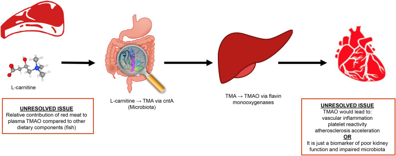

Fig. 3. Underlying mechanisms of the pathophysiological effects of carnitine on CVD.

Nevertheless, a diet enriched in red meat compared to white meat has been associated with increased blood TMAO levels (Koeth et al., 2013). This relationship is explained by the increased microbial TMA/TMAO production from carnitine. A discontinuation of red meat intake reduced plasma TMAO levels within 4 weeks (Wang et al., 2019). Taking only this information into consideration, the reduction of red meat within a healthy diet should be recommended. However, carnitine exerts positive effects as mentioned above, and most importantly, the TMAO formed from carnitine is largely dependent on the microbial population of the gut and the presence of dietary substances with ability to inhibit the TMA synthesis from carnitine, such as resveratrol or allicin (Chen et al., 2016; Wu et al., 2015). Other authors have found different TMAO blood levels in diabetic and non-diabetic cardiac patients, being strongly associated with different patterns of the intestinal microbiota (Sanchez-Alcoholado et al., 2017). Diabetic cardiac patients had higher TMAO levels, linked with less beneficial or commensal bacteria (such as *Faecalibacterium prausnitzii* and *Bacteroides fragilis*) and more opportunistic pathogens (such as *Enterobacteriaceae*, *Streptococcus*, and *Desulfovibrio*). The gut microbiota can, therefore, be proposed as a therapeutic target to reduce TMAO levels and thus the risk of CVD. Diet is considered to have the largest influence on gut microbial population makeup and function (Sheflin, Melby, Carbonero, & Weir, 2017). In fact, enterotypes have been clearly associated with long-term diets, particularly those rich in protein and animal fat in which *Bacteroides* was the prevalent genus, versus carbohydrate-rich diets in which *Prevotella* was mainly found (Wu et al., 2011). Changes in diet are able to modulate the microbiota depending on the amount, type and balance of the main dietary macronutrients (Scott, Gratz, Sheridan, Flint, & Duncan, 2013). For instance, urinary TMAO levels were lower when pigs consumed red meat in the context of a prudent vs. a western background diet (Thøgersen et al., 2020). However, healthy diets are not always followed by consumers in general, and by patients in particular. Therefore, the direct administration of pre- and/or probiotics might be a strategy to follow in order to modulate the gut microbiota in a beneficial way.

Several substances have been described as microbial TMA inhibitors, thereupon reducing TMAO blood levels. For instance, a significant reduction in TMAO level was achieved through antibiotic administration, but TMAO blood levels were increased after antibiotics were discontinued (Tang et al., 2013). However, the chronic administration of antibiotics is not recommended, thus, other alternatives have been investigated. The ability of a choline analogue (3,3-dimethyl-1-butanol (DMB)) to inhibit TMA production and reduce TMAO levels in mice fed a high choline or carnitine diet, without microbial growth inhibition, has been demonstrated (Wang et al., 2015). A carnitine analogue, meldonium, also significantly reduced the production of TMA/TMAO from L-carnitine, but not from choline, and neither affected bacterial growth (Kuka et al., 2014). Resveratrol, an antioxidant commonly found in red berries, has also been found to decrease plasma levels of TMA and TMAO (Annunziata et al., 2019). This antioxidant and antimicrobial substance achieved this reduction by modulating the microbiota, inhibiting commensal microbial TMA producers and increasing levels of the genera *Lactobacillus* and *Bifidobacterium* (Chen et al., 2016). Similarly, allicin, a potent antimicrobial found in garlic, significantly reduced TMAO blood levels in mice fed with carnitine, through gut microbiota modulation (Wu et al., 2015).

## 4. Concluding remarks

Particular components of red and processed meat products discussed herewithin, namely, lipids and oxidized lipids, NaCl and carnitine, are associated to contribute to the occurrence of cardiovascular events by diverse means. Yet, the role of single components in chronic diseases cannot be easily extrapolated to the contribution of muscle foods containing such components. In fact, epidemiological studies reveal no authoritative connections between the intake of red and processed meat and occurrence of CVD. Taking into consideration current scientific literature leads to inconsistencies and contradictory outcomes in relation to the influence of meat lipids and carnitine on CVD. The influence of dietary lipids on lipid metabolism and CVD is multifaceted and lipid oxidation may partly account for the negative impact of such relationship. Since dietary components such as fish, recurrently recognized as cardioprotective, leads to considerably higher formation of n-3 PUFA oxidation products during digestion and higher plasma levels of TMAO than red meat, the intertwined role of lipid oxidation, carnitine and TMAO as promoters of increased blood pressure needs to be critically assessed. The contribution of processed meat to total NaCl intake, and the concomitant effect on CVD is likely the most established relationship discussed in this review. Hence, sodium reduction and/or replacement in meat processing is expected to have mitigating effects on CVD. Continued efforts should, therefore, be made by the meat industry to improve the formulation of processed meats so that they keep playing a relevant role in a healthy and nutritious diet.

## Declaration of Competing Interest

The authors declare that they have no known competing financial interests or personal relationships that could have appeared to influence the work reported in this paper.

## Acknowledgements

Josué Delgado acknowledges the Health Council of the Andalusian Regional Government (project ID: PI-0170-2018). Mario Estévez acknowledges the Spanish Ministry of Economy and Competitiveness (project ID: AGL2017-84586R). Thomas Van Hecke is supported as postdoctoral fellow from the Research Foundation Flanders (FWO-Vlaanderen; 12V5119N). Universidad de Navarra acknowledges Plan de Investigación de la Universidad de Navarra (PIUNA) and RED CONSOLIDER AGL2017-90699-REDC.

## References

**Abete et al., 2014**

I. Abete, D. Romaguera, A.R. Vieira, A. Lopez de Munain, T. Norat**Association between total, processed, red and white meat consumption and all-cause, CVssD and IHD mortality: a meta-analysis of cohort studies**

British Journal of Nutrition, 112 (5) (2014), pp. 762-775, 10.1017/s000711451400124x

[View Record in Scopus](https://www.scopus.com/inward/record.url?eid=2-s2.0-84907598133&partnerID=10&rel=R3.0.0)Google Scholar

**Ahotupa, 2017**

M. Ahotupa**Oxidized lipoprotein lipids and atherosclerosis**

Free Radical Research, 51 (4) (2017), pp. 439-447, 10.1080/10715762.2017.1319944

[CrossRef](https://doi.org/10.1080/10715762.2017.1319944)[View Record in Scopus](https://www.scopus.com/inward/record.url?eid=2-s2.0-85019491128&partnerID=10&rel=R3.0.0)[Google Scholar](https://scholar.google.com/scholar_lookup?title=Oxidized%20lipoprotein%20lipids%20and%20atherosclerosis&publication_year=2017&author=M.%20Ahotupa)

**Alejandre et al., 2019**

M. Alejandre, I. Astiasarán, D. Ansorena**Omega-3 fatty acids and plant sterols as cardioprotective ingredients in beef patties: composition and relevance of nutritional information on sensory characterization**

Food & Function, 10 (12) (2019), pp. 7883-7891, 10.1039/C9FO01128E

[CrossRef](https://doi.org/10.1039/c9fo01128e)[View Record in Scopus](https://www.scopus.com/inward/record.url?eid=2-s2.0-85076382314&partnerID=10&rel=R3.0.0)Google Scholar

**Allison and Fouladkhah, 2018**

A. Allison, A. Fouladkhah**Adoptable interventions, human health, and food safety considerations for reducing sodium content of processed food products**

Foods, 7 (2) (2018), p. 16, 10.3390/foods7020016

Google Scholar

**Annunziata et al., 2019**

G. Annunziata, M. Maisto, C. Schisano, R. Ciampaglia, V. Narciso, G.C. Tenore, E. Novellino**Effects of grape pomace polyphenolic extract (Taurisolo ®) in reducing TMAO serum levels in humans: Preliminary results from a randomized, placebo-controlled, cross-over study**

Nutrients, 11 (1) (2019), 10.3390/nu11010139

Google Scholar

**Ansorena and Astiasarán, 2014**

D. Ansorena, I. Astiasarán**Functional Dry Fermented Sausages**

Handbook of Fermented Meat and Poultry. Chaptr 28. Pp. 241-250, John Wiley & Sons, Ltd (2014)

Edited by Fidel Toldrá, Iciar Astiasaran, Joseph Sebranek, Regine Talon. ISBN:9781118522691

[Google Scholar](https://scholar.google.com/scholar_lookup?title=Functional%20Dry%20Fermented%20Sausages&publication_year=2014&author=D.%20Ansorena&author=I.%20Astiasar%C3%A1n)

**Armenteros et al., 2012**

M. Armenteros, M.C. Aristoy, J.M. Barat, F. Toldrá**Biochemical and sensory changes in dry-cured ham salted with partial replacements of NaCl by other chloride salts**

Meat Science, 90 (2) (2012), pp. 361-367, 10.1016/j.meatsci.2011.07.023

[Article](https://www.sciencedirect.com/science/article/pii/S0309174011002737)[Download PDF](https://www.sciencedirect.com/science/article/pii/S0309174011002737/pdfft?md5=898d0effcbc26d6e604c0ba747175eed&pid=1-s2.0-S0309174011002737-main.pdf)[View Record in Scopus](https://www.scopus.com/inward/record.url?eid=2-s2.0-80555150712&partnerID=10&rel=R3.0.0)Google Scholar

**Bacs et al., 2019**

Z. Bacs, K. Szabo, L. Czegledi, J. Nemeth, P. Fraknoi, P. Kovacs, Z. Szilvassy**Effect of broth from meat of linseed-fed cattle on glucose-stimulated insulin release in healthy male volunteers**

Animal Science Journal, 90 (6) (2019), pp. 769-773, 10.1111/asj.13193

[CrossRef](https://doi.org/10.1111/asj.13193)[View Record in Scopus](https://www.scopus.com/inward/record.url?eid=2-s2.0-85064476443&partnerID=10&rel=R3.0.0)Google Scholar

**Berger et al., 2015**

S. Berger, G. Raman, R. Vishwanathan, P.F. Jacques, E.J. Johnson**Dietary cholesterol and cardiovascular disease: A systematic review and meta-analysis**

American Journal of Clinical Nutrition, 102 (2) (2015), pp. 276-294, 10.3945/ajcn.114.100305

[CrossRef](https://doi.org/10.3945/ajcn.114.100305)[View Record in Scopus](https://www.scopus.com/inward/record.url?eid=2-s2.0-84938678768&partnerID=10&rel=R3.0.0)Google Scholar

**Borlaug et al., 2015**

B.A. Borlaug, K.E. Koepp, V. Melenovsky**Sodium nitrite improves exercise hemodynamics and ventricular performance in heart failure with preserved ejection fraction**

Journal of the American College of Cardiology, 66 (15) (2015), pp. 1672-1682, 10.1016/j.jacc.2015.07.067

[Article](https://www.sciencedirect.com/science/article/pii/S0735109715048573)[Download PDF](https://www.sciencedirect.com/science/article/pii/S0735109715048573/pdfft?md5=5780c9a5b424fe613d373130096111b5&pid=1-s2.0-S0735109715048573-main.pdf)[View Record in Scopus](https://www.scopus.com/inward/record.url?eid=2-s2.0-84943264616&partnerID=10&rel=R3.0.0)Google Scholar

**Bowen et al., 2018**

K.J. Bowen, V.K. Sullivan, P.M. Kris-Etherton, K.S. Petersen**Nutrition and cardiovascular disease—an update**

Current Atherosclerosis Reports, 20 (2) (2018), Article 8, 10.1007/s11883-018-0704-3

[View Record in Scopus](https://www.scopus.com/inward/record.url?eid=2-s2.0-85074142460&partnerID=10&rel=R3.0.0)[Google Scholar](https://scholar.google.com/scholar?q=Nutrition%20and%20cardiovascular%20diseasean%20update)

**Brown et al., 2009**

I.J. Brown, I. Tzoulaki, V. Candeias, P. Elliott**Salt intakes around the world: Implications for public health**

International Journal of Epidemiology, 38 (3) (2009), pp. 791-813, 10.1093/ije/dyp139

[CrossRef](https://doi.org/10.1093/ije/dyp139)[View Record in Scopus](https://www.scopus.com/inward/record.url?eid=2-s2.0-66849093848&partnerID=10&rel=R3.0.0)Google Scholar

**Buckley and Ramji, 2015**

M.L. Buckley, D.P. Ramji**The influence of dysfunctional signaling and lipid homeostasis in mediating the inflammatory responses during atherosclerosis**

Biochimica et Biophysica Acta - Molecular Basis of Disease, 1852 (7) (2015), pp. 1498-1510, 10.1016/j.bbadis.2015.04.011

[Article](https://www.sciencedirect.com/science/article/pii/S0925443915001179)[Download PDF](https://www.sciencedirect.com/science/article/pii/S0925443915001179/pdfft?md5=73366d9984c275516e787e96bf68f8dd&pid=1-s2.0-S0925443915001179-main.pdf)[View Record in Scopus](https://www.scopus.com/inward/record.url?eid=2-s2.0-84928555600&partnerID=10&rel=R3.0.0)Google Scholar

**Canales et al., 2011**

A. Canales, F.J. Sánchez-Muniz, S. Bastida, J. Librelotto, M. Nus, D. Corella, ..., J. Benedi**Effect of walnut-enriched meat on the relationship between VCAM, ICAM, and LTB4 levels and PON-1 activity in ApoA4 360 and PON-1 allele carriers at increased cardiovascular risk**

European Journal of Clinical Nutrition, 65 (6) (2011), pp. 703-710, 10.1038/ejcn.2011.20

[CrossRef](https://doi.org/10.1038/ejcn.2011.20)[View Record in Scopus](https://www.scopus.com/inward/record.url?eid=2-s2.0-79958046629&partnerID=10&rel=R3.0.0)Google Scholar

**Centers for Disease Control and Prevention, 2011**

Centers for Disease Control and Prevention**Vital signs: Food categories contributing the most to sodium consumption — United States, 2007–2008**

Morbidity and Mortality Weekly, 61 (2011), pp. 92-98

[Google Scholar](https://scholar.google.com/scholar?q=Vital%20signs:%20Food%20categories%20contributing%20the%20most%20to%20sodium%20consumption%20%20United%20States,%2020072008)

**Chen et al., 2013**

G.C. Chen, D.B. Lv, Z. Pang, Q.F. Liu**Red and processed meat consumption and risk of stroke: A meta-analysis of prospective cohort studies**

European Journal of Clinical Nutrition, 67 (1) (2013), pp. 91-95, 10.1038/ejcn.2012.180

[CrossRef](https://doi.org/10.1007/s10529-012-1053-x)[View Record in Scopus](https://www.scopus.com/inward/record.url?eid=2-s2.0-84870589285&partnerID=10&rel=R3.0.0)Google Scholar

**Chen et al., 2016**

M. Chen, L. Yi, Y. Zhang, X. Zhou, L. Ran, J. Yang, ..., M. Mi**Resveratrol attenuates Trimethylamine-N-oxide (TMAO)-induced atherosclerosis by regulating TMAO synthesis and bile acid metabolism via remodeling of the gut microbiota**

MBio, 7 (2) (2016), pp. 1-14, 10.1128/mBio.02210-15.Invited

[CrossRef](https://doi.org/10.3390/bdcc1010001)[View Record in Scopus](https://www.scopus.com/inward/record.url?eid=2-s2.0-85087481265&partnerID=10&rel=R3.0.0)Google Scholar

**Cho et al., 2017**

C.E. Cho, S. Taesuwan, O.V. Malysheva, E. Bender, N.F. Tulchinsky, J. Yan, ..., M.A. Caudill**Trimethylamine-N-oxide (TMAO) response to animal source foods varies among healthy young men and is influenced by their gut microbiota composition: A randomized controlled trial**

Molecular Nutrition and Food Research, 61 (1) (2017), pp. 1-12, 10.1002/mnfr.201600324

[View Record in Scopus](https://www.scopus.com/inward/record.url?eid=2-s2.0-85083667230&partnerID=10&rel=R3.0.0)Google Scholar

**Choi et al., 2016**

S.E. Choi, M.L. Brandeau, S. Basu**Expansion of the national salt reduction initiative: A mathematical model of benefits and risks of population-level sodium reduction**

Medical Decision Making, 36 (14) (2016), pp. 72-85, 10.1016/j.bbi.2017.04.008

[CrossRef](https://doi.org/10.1177/0272989X15583846)[View Record in Scopus](https://www.scopus.com/inward/record.url?eid=2-s2.0-84950117480&partnerID=10&rel=R3.0.0)Google Scholar

**Chrysant, 2016**

S.G. Chrysant**Effects of high salt intake on blood pressure and cardiovascular disease: the role of COX inhibitors**

Clinical Cardiology, 39 (4) (2016), pp. 240-242, 10.1002/clc.22536

[CrossRef](https://doi.org/10.1002/clc.22536)[View Record in Scopus](https://www.scopus.com/inward/record.url?eid=2-s2.0-84962534324&partnerID=10&rel=R3.0.0)Google Scholar

**Costanzo and Jessup, 2012**

M.R. Costanzo, M. Jessup**Treatment of congestion in heart failure with diuretics and extracorporeal therapies: Effects on symptoms, renal function, and prognosis**

Heart Failure Reviews, 17 (2) (2012), pp. 313-324, 10.1007/s10741-011-9248-0

[CrossRef](https://doi.org/10.1007/s10741-011-9248-0)[View Record in Scopus](https://www.scopus.com/inward/record.url?eid=2-s2.0-84862586284&partnerID=10&rel=R3.0.0)Google Scholar

**Das et al., 2020**

A.K. Das, P.K. Nanda, P. Madane, W. Zhang, J.M. Lorenzo**A comprehensive review on antioxidant dietary fibre enriched meat-based functional foods**

Trends in Food Science and Technology, 99 (2020), pp. 323-336, 10.1016/j.tifs.2020.03.010

[Article](https://www.sciencedirect.com/science/article/pii/S0924224419308349)[Download PDF](https://www.sciencedirect.com/science/article/pii/S0924224419308349/pdfft?md5=e0173082a7a42efc2724ac14b3a06adb&pid=1-s2.0-S0924224419308349-main.pdf)[View Record in Scopus](https://www.scopus.com/inward/record.url?eid=2-s2.0-85081733865&partnerID=10&rel=R3.0.0)Google Scholar

**De Smet and Vossen, 2016**

S. De Smet, E. Vossen**Meat: The balance between nutrition and health. A review**

Meat Science, 120 (2016), pp. 145-156, 10.1016/j.meatsci.2016.04.008

[Article](https://www.sciencedirect.com/science/article/pii/S0309174016301012)[Download PDF](https://www.sciencedirect.com/science/article/pii/S0309174016301012/pdfft?md5=4b733123395f0d2863c03399b9c61f2b&pid=1-s2.0-S0309174016301012-main.pdf)[View Record in Scopus](https://www.scopus.com/inward/record.url?eid=2-s2.0-84963972144&partnerID=10&rel=R3.0.0)[Google Scholar](https://scholar.google.com/scholar_lookup?title=Meat%3A%20The%20balance%20between%20nutrition%20and%20health.%20A%20review&publication_year=2016&author=S.%20De%20Smet&author=E.%20Vossen)

**Dehghan et al., 2017**

M. Dehghan, A. Mente, X. Zhang, S. Swaminathan, W. Li, V. Mohan, ..., R. Mapanga**Associations of fats and carbohydrate intake with cardiovascular disease and mortality in 18 countries from five continents (PURE): a prospective cohort study**

The Lancet, 390 (10107) (2017), pp. 2050-2062, 10.1016/S0140-6736(17)32252-3

[Article](https://www.sciencedirect.com/science/article/pii/S0140673617322523)[Download PDF](https://www.sciencedirect.com/science/article/pii/S0140673617322523/pdfft?md5=ce5e23b29fa623c4de72052aca165426&pid=1-s2.0-S0140673617322523-main.pdf)[View Record in Scopus](https://www.scopus.com/inward/record.url?eid=2-s2.0-85028462455&partnerID=10&rel=R3.0.0)Google Scholar

**Demarquoy et al., 2004**

J. Demarquoy, B. Georges, C. Rigault, M.C. Royer, A. Clairet, M. Soty, ..., F. Le Borgne**Radioisotopic determination of L-carnitine content in foods commonly eaten in Western countries**

Food Chemistry, 86 (1) (2004), pp. 137-142, 10.1016/j.foodchem.2003.09.023

[Article](https://www.sciencedirect.com/science/article/pii/S0308814603004886)[Download PDF](https://www.sciencedirect.com/science/article/pii/S0308814603004886/pdfft?md5=f787747c453ee303e3b5072323ed53dd&pid=1-s2.0-S0308814603004886-main.pdf)[View Record in Scopus](https://www.scopus.com/inward/record.url?eid=2-s2.0-1042266294&partnerID=10&rel=R3.0.0)Google Scholar

**Demeyer et al., 2016**

D. Demeyer, B. Mertens, S. De Smet, M. Ulens**Mechanisms linking colorectal cancer to the consumption of (processed) red meat: a review**

Critical Reviews in Food Science and Nutrition, 56 (16) (2016), pp. 2746-2766, 10.1080/10408398.2013.873886

[Google Scholar](https://scholar.google.com/scholar?q=Mechanisms%20linking%20colorectal%20cancer%20to%20the%20consumption%20of%20%20red%20meat:%20a%20review)

**Diane et al., 2016**

A. Diane, F. Borthwick, C. Mapiye, P. Vahmani, R.C. David, D.F. Vine, S.D. Proctor**Beef fat enriched with polyunsaturated fatty acid biohydrogenation products improves insulin sensitivity without altering dyslipidemia in insulin resistant JCR:LA-cp rats**

Lipids, 51 (7) (2016), pp. 821-831, 10.1007/s11745-016-4148-7

[CrossRef](https://doi.org/10.1007/s11745-016-4148-7)[View Record in Scopus](https://www.scopus.com/inward/record.url?eid=2-s2.0-84963648069&partnerID=10&rel=R3.0.0)Google Scholar

**Dinh et al., 2011**

T.T.N. Dinh, L.D. Thompson, M.L. Galyean, K.Y. Patterson, L.M. Boylan**Cholesterol content and methods for cholesterol determination in meat and poultry**

Comprehensive Reviews in Food Science and Food Safety, 10 (5) (2011), pp. 269-289, 10.1111/j.1541-4337.2011.00158.x

[CrossRef](https://doi.org/10.1111/j.1541-4337.2011.00158.x)[View Record in Scopus](https://www.scopus.com/inward/record.url?eid=2-s2.0-80051893044&partnerID=10&rel=R3.0.0)Google Scholar

**DiNicolantonio et al., 2013**

J.J. DiNicolantonio, C.J. Lavie, H. Fares, A.R. Menezes, J.H. O’Keefe**L-carnitine in the secondary prevention of cardiovascular disease: Systematic review and meta-analysis**

Mayo Clinic Proceedings, 88 (6) (2013), pp. 544-551, 10.1016/j.mayocp.2013.02.007

[Article](https://www.sciencedirect.com/science/article/pii/S0025619613001274)[Download PDF](https://www.sciencedirect.com/science/article/pii/S0025619613001274/pdfft?md5=5c43f96ecebdd577c4b963eca7fc2801&pid=1-s2.0-S0025619613001274-main.pdf)[View Record in Scopus](https://www.scopus.com/inward/record.url?eid=2-s2.0-84880197534&partnerID=10&rel=R3.0.0)Google Scholar

**Dugan et al., 2011**

M.E.R. Dugan, N. Aldai, J.L. Aalhus, D.C. Rolland, J.K.G. Kramer**Review: Trans-forming beef to provide healthier fatty acid profiles**

Canadian Journal of Animal Science, 91 (2011), pp. 545-556, 10.4141/CJAS2011-044

[CrossRef](https://doi.org/10.4141/cjas2011-044)[View Record in Scopus](https://www.scopus.com/inward/record.url?eid=2-s2.0-84861122681&partnerID=10&rel=R3.0.0)Google Scholar

**Eckel et al., 2014**

R.H. Eckel, J.M. Jakicic, J.D. Ard, J.M. De Jesus, N.H. Miller, V.S. Hubbard, ..., G.F. Tomaselli**Reprint: 2013 AHA/ACC guideline on lifestyle management to reduce cardiovascular risk**

Journal of the American Pharmacists Association : JAPhA, 54 (1) (2014), pp. s76-s99, 10.1331/JAPhA.2014.14501

[Google Scholar](https://scholar.google.com/scholar?q=Reprint:%202013%20AHAACC%20guideline%20on%20lifestyle%20management%20to%20reduce%20cardiovascular%20risk)

**EFSA, 2010**

EFSA**Scientific opinion on dietary reference values for fats, including saturated fatty acids, polyunsaturated fatty acids, monounsaturated fatty acids, trans fatty acids, and cholesterol**

EFSA Journal, 8 (3) (2010), pp. 1-107, 10.2903/j.efsa.2010.1461

[View Record in Scopus](https://www.scopus.com/inward/record.url?eid=2-s2.0-84855539294&partnerID=10&rel=R3.0.0)Google Scholar

**Ekmekcioglu et al., 2018**

C. Ekmekcioglu, P. Wallner, M. Kundi, U. Weisz, W. Haas, H.-P. Hutter**Red meat, diseases, and healthy alternatives: A critical review**

Critical Reviews in Food Science and Nutrition, 58 (2) (2018), pp. 247-261, 10.1080/10408398.2016.1158148

[CrossRef](https://doi.org/10.1080/10408398.2016.1158148)[View Record in Scopus](https://www.scopus.com/inward/record.url?eid=2-s2.0-85021444873&partnerID=10&rel=R3.0.0)Google Scholar

**Farquhar et al., 2015**

W.B. Farquhar, D.G. Edwards, C.T. Jurkovitz, W.S. Weintraub**Dietary sodium and health: More than just blood pressure**

Journal of the American College of Cardiology, 65 (10) (2015), pp. 1042-1050, 10.1016/j.jacc.2014.12.039

[Article](https://www.sciencedirect.com/science/article/pii/S0735109715000832)[Download PDF](https://www.sciencedirect.com/science/article/pii/S0735109715000832/pdfft?md5=aca71c16e804681ee8287e6b3a04c67d&pid=1-s2.0-S0735109715000832-main.pdf)[View Record in Scopus](https://www.scopus.com/inward/record.url?eid=2-s2.0-84924351706&partnerID=10&rel=R3.0.0)Google Scholar

**Fisher et al., 2003**

N.D.L. Fisher, M. Hughes, M. Gerhard-Herman, N.K. Hollenberg**Flavanol-rich cocoa induces nitric-oxide-dependent vasodilation in healthy humans Naomi**

Journal of Hypertension, 21 (12) (2003), pp. 2281-2286, 10.1097/01.hjh.0000084783.15238.eb

[View Record in Scopus](https://www.scopus.com/inward/record.url?eid=2-s2.0-1442274617&partnerID=10&rel=R3.0.0)Google Scholar

**Forsythe et al., 2008**

C.E. Forsythe, S.D. Phinney, M.L. Fernandez, E.E. Quann, R.J. Wood, D.M. Bibus, ..., J.S. Volek**Comparison of low fat and low carbohydrate diets on circulating fatty acid composition and markers of inflammation**

Lipids, 43 (1) (2008), pp. 65-77, 10.1007/s11745-007-3132-7

[CrossRef](https://doi.org/10.1007/s11745-007-3132-7)[View Record in Scopus](https://www.scopus.com/inward/record.url?eid=2-s2.0-39149141607&partnerID=10&rel=R3.0.0)Google Scholar

**Fretts et al., 2014**

A.M. Fretts, D. Mozaffarian, D.S. Siscovick, L. Djousse, S.R. Heckbert, I.B. King, ..., R.N. Lemaitre**Plasma phospholipid saturated fatty acids and incident atrial fibrillation: The Cardiovascular health study**

Journal of the American Heart Association, 3 (3) (2014), pp. 1-10, 10.1161/JAHA.114.000889

Google Scholar

**Gidding and Allen, 2019**

S.S. Gidding, N.B. Allen**Cholesterol and atherosclerotic cardiovascular disease: A lifelong problem**

Journal of the American Heart Association, 8 (11) (2019), pp. 1-3, 10.1161/JAHA.119.012924

[Google Scholar](https://scholar.google.com/scholar_lookup?title=Cholesterol%20and%20atherosclerotic%20cardiovascular%20disease%3A%20A%20lifelong%20problem&publication_year=2019&author=S.S.%20Gidding&author=N.B.%20Allen)

**Gorelik et al., 2013**

S. Gorelik, J. Kanner, D. Schurr, R. Kohen**A rational approach to prevent postprandial modification of LDL by dietary polyphenols**

Journal of Functional Foods, 5 (1) (2013), pp. 163-169, 10.1016/j.jff.2012.09.008

[Article](https://www.sciencedirect.com/science/article/pii/S1756464612001466)[Download PDF](https://www.sciencedirect.com/science/article/pii/S1756464612001466/pdfft?md5=5abf69a3c1c1653399f1d811f904c656&pid=1-s2.0-S1756464612001466-main.pdf)[View Record in Scopus](https://www.scopus.com/inward/record.url?eid=2-s2.0-84873270715&partnerID=10&rel=R3.0.0)Google Scholar

**Grundy, 2016**

S.M. Grundy**Does dietary cholesterol matter?**

Current Atherosclerosis Reports, 18 (11) (2016), pp. 1-7, 10.1007/s11883-016-0615-0

[View Record in Scopus](https://www.scopus.com/inward/record.url?eid=2-s2.0-85052115008&partnerID=10&rel=R3.0.0)[Google Scholar](https://scholar.google.com/scholar?q=Does%20dietary%20cholesterol%20matter)

**HHS and USDA, 2015**

HHS & USDA**U.S. Department of Health and Human Services and U.S. Department of Agriculture. 2015–2020 Dietary Guidelines for Americans**

(8th ed.) (2015)

December 2015. Available at

http://health.gov/dietaryguidelines/2015/guidelines/

[Google Scholar](https://scholar.google.com/scholar?q=U.S.%20Department%20of%20Health%20and%20Human%20Services%20and%20U.S.%20Department%20of%20Agriculture.%2020152020%20Dietary%20Guidelines%20for%20Americans)

**Hoenselaar, 2012**

R. Hoenselaar**Saturated fat and cardiovascular disease: The discrepancy between the scientific literature and dietary advice**

Nutrition, 28 (2) (2012), pp. 118-123, 10.1016/j.nut.2011.08.017

[Article](https://www.sciencedirect.com/science/article/pii/S0899900711003145)[Download PDF](https://www.sciencedirect.com/science/article/pii/S0899900711003145/pdfft?md5=4c22004b8f7b5340940a880d8967cfc7&pid=1-s2.0-S0899900711003145-main.pdf)[View Record in Scopus](https://www.scopus.com/inward/record.url?eid=2-s2.0-84855215993&partnerID=10&rel=R3.0.0)Google Scholar

**Hulshof et al., 1999**

K.F.A.M. Hulshof, M.A. Van Erp-Baart, M. Anttolainen, W. Becker, S.M. Church, C. Couet, ..., G. Van Poppel**Intake of fatty acids in Western Europe with emphasis on trans fatty acids: The TRANSFAIR study**

European Journal of Clinical Nutrition, 53 (2) (1999), pp. 143-157, 10.1038/sj.ejcn.1600692

[CrossRef](https://doi.org/10.1038/sj.ejcn.1600692)[View Record in Scopus](https://www.scopus.com/inward/record.url?eid=2-s2.0-0033032003&partnerID=10&rel=R3.0.0)Google Scholar

**Hunter et al., 2010**

J.E. Hunter, J. Zhang, P.M. Kris-Etherton, L. Childs**Cardiovascular disease risk of dietary stearic acid compared with trans, other saturated, and unsaturated fatty acids: A systematic review**

American Journal of Clinical Nutrition, 91 (1) (2010), pp. 46-63, 10.3945/ajcn.2009.27661

[CrossRef](https://doi.org/10.3945/ajcn.2009.27661)[View Record in Scopus](https://www.scopus.com/inward/record.url?eid=2-s2.0-74049131670&partnerID=10&rel=R3.0.0)Google Scholar

**Jablonski et al., 2013**

K.L. Jablonski, M.L. Racine, C.J. Geolfos, P.E. Gates, M. Chonchol, M.B. McQueen, D.R. Seals**Dietary sodium restriction reverses vascular endothelial dysfunction in middle-aged/older adults with moderately elevated systolic blood pressure**

Journal of the American College of Cardiology, 61 (3) (2013), pp. 335-343, 10.1016/j.jacc.2012.09.010

[Article](https://www.sciencedirect.com/science/article/pii/S0735109712046359)[Download PDF](https://www.sciencedirect.com/science/article/pii/S0735109712046359/pdfft?md5=d042150eadc30b896532fbbfb501fcff&pid=1-s2.0-S0735109712046359-main.pdf)[View Record in Scopus](https://www.scopus.com/inward/record.url?eid=2-s2.0-84872332944&partnerID=10&rel=R3.0.0)Google Scholar

**Jacobson et al., 2015**

T.A. Jacobson, M.K. Ito, K.C. Maki, C.E. Orringer, H.E. Bays, P.H. Jones, ..., W.V. Brown**National Lipid Association recommendations for patient-centered management of dyslipidemia: Part 1 - Full report**

Journal of Clinical Lipidology, 9 (2) (2015), pp. 129-169, 10.1016/j.jacl.2015.02.003

[Article](https://www.sciencedirect.com/science/article/pii/S1933287415000598)[Download PDF](https://www.sciencedirect.com/science/article/pii/S1933287415000598/pdfft?md5=f388003d478b04f555e57bb7aa66bd9b&pid=1-s2.0-S1933287415000598-main.pdf)[View Record in Scopus](https://www.scopus.com/inward/record.url?eid=2-s2.0-84928823445&partnerID=10&rel=R3.0.0)Google Scholar

**Johnston et al., 2019**

B.C. Johnston, D. Zeraatkar, M.A. Han, R.W.M. Vernooij, C. Valli, R. El Dib, ..., G.H. Guyatt**Unprocessed red meat and processed meat consumption: Dietary guideline recommendations from the nutritional recommendations (NUTRIRECS) consortium**

Annals of Internal Medicine, 171 (10) (2019), pp. 756-764, 10.7326/M19-1621

[CrossRef](https://doi.org/10.7326/m19-1621)[View Record in Scopus](https://www.scopus.com/inward/record.url?eid=2-s2.0-85073540462&partnerID=10&rel=R3.0.0)[Google Scholar](https://scholar.google.com/scholar?q=Unprocessed%20red%20meat%20and%20processed%20meat%20consumption:%20Dietary%20guideline%20recommendations%20from%20the%20nutritional%20recommendations%20%20consortium)

**Joseph et al., 2019**

L.C. Joseph, U.M.R. Avula, E.Y. Wan, M.V. Reyes, K.R. Lakkadi, P. Subramanyam, ..., J.P. Morrow**dietary saturated fat promotes arrhythmia by activating NOX2 (NADPH Oxidase 2)**

Circulation: Arrhythmia and Electrophysiology, 12 (11) (2019), pp. 1-12, 10.1161/CIRCEP.119.007573

[CrossRef](https://doi.org/10.1155/2019/2476565)[View Record in Scopus](https://www.scopus.com/inward/record.url?eid=2-s2.0-85071511842&partnerID=10&rel=R3.0.0)[Google Scholar](https://scholar.google.com/scholar?q=dietary%20saturated%20fat%20promotes%20arrhythmia%20by%20activating%20NOX2)

**Kaluza et al., 2012**

J. Kaluza, A. Wolk, S.C. Larsson**Red meat consumption and risk of stroke: A meta-analysis of prospective studies**

Stroke, 43 (10) (2012), pp. 2556-2560, 10.1161/STROKEAHA.112.663286

[View Record in Scopus](https://www.scopus.com/inward/record.url?eid=2-s2.0-84866636113&partnerID=10&rel=R3.0.0)Google Scholar

**Kanner et al., 2012**

J. Kanner, S. Gorelik, S. Roman, R. Kohen**Protection by polyphenols of postprandial human plasma and low-density lipoprotein modification: The stomach as a bioreactor**

Journal of Agricultural and Food Chemistry, 60 (36) (2012), pp. 8790-8796, 10.1021/jf300193g

[CrossRef](https://doi.org/10.1021/jf300193g)[View Record in Scopus](https://www.scopus.com/inward/record.url?eid=2-s2.0-84866392769&partnerID=10&rel=R3.0.0)Google Scholar

**Kapil et al., 2010**

V. Kapil, A.B. Milsom, M. Okorie, S. Maleki-Toyserkani, F. Akram, F. Rehman, ..., A. Ahluwalia**Inorganic nitrate supplementation lowers blood pressure in humans: Role for nitrite-derived no**

Hypertension, 56 (2) (2010), pp. 274-281, 10.1161/HYPERTENSIONAHA.110.153536

[View Record in Scopus](https://www.scopus.com/inward/record.url?eid=2-s2.0-77955476126&partnerID=10&rel=R3.0.0)Google Scholar

**Keeton and Dikeman, 2017**

J.T. Keeton, M.E. Dikeman**‘Red’ and ‘white’ meats-terms that lead to confusion**

Animal Frontiers, 7 (4) (2017), pp. 29-33, 10.2527/af.2017.0440

[CrossRef](https://doi.org/10.2527/af.2017.0440)[View Record in Scopus](https://www.scopus.com/inward/record.url?eid=2-s2.0-85050911851&partnerID=10&rel=R3.0.0)[Google Scholar](https://scholar.google.com/scholar?q=Red%20and%20white%20meats-terms%20that%20lead%20to%20confusion)

**Kim et al., 2017**

K. Kim, J. Hyeon, S.A. Lee, S.O. Kwon, H. Lee, N.N. Keum, ..., S.M. Park**Role of total, red, processed, and white meat consumption in stroke incidence and mortality: A systematic review and meta-analysis of prospective cohort studies**

Journal of the American Heart Association, 6 (9) (2017), 10.1161/JAHA.117.005983

Google Scholar

**Kloss et al., 2015**

L. Kloss, J.D. Meyer, L. Graeve, W. Vetter**Sodium intake and its reduction by food reformulation in the European Union - A review**

NFS Journal, 1 (2015), pp. 9-19, 10.1016/j.nfs.2015.03.001

[Article](https://www.sciencedirect.com/science/article/pii/S2352364615000024)[Download PDF](https://www.sciencedirect.com/science/article/pii/S2352364615000024/pdfft?md5=4fa8264242c067aac6fd4bc5f2cb47ac&pid=1-s2.0-S2352364615000024-main.pdf)[View Record in Scopus](https://www.scopus.com/inward/record.url?eid=2-s2.0-84944064022&partnerID=10&rel=R3.0.0)Google Scholar

**Knüttel-Gustavsen and Harmeyer, 2011**

S. Knüttel-Gustavsen, J. Harmeyer**The content of L-carnitine in meat after different methods of heat treatment**

British Food Journal, 113 (9) (2011), pp. 1114-1126, 10.1108/00070701111174569

[CrossRef](https://doi.org/10.1108/00070701111174569)[View Record in Scopus](https://www.scopus.com/inward/record.url?eid=2-s2.0-80053082482&partnerID=10&rel=R3.0.0)Google Scholar

**Koeth et al., 2013**

R.A. Koeth, Z. Wang, B.S. Levison, J.A. Buffa, E. Org, B.T. Sheehy, ..., S. L**Intestinal microbiota metabolism of L-carnitine, a nutrient in red meat, promotes atherosclerosis**

Nature Medicine, 19 (5) (2013), pp. 576-585, 10.1038/nm.3145

[CrossRef](https://doi.org/10.1038/nm.3145)[View Record in Scopus](https://www.scopus.com/inward/record.url?eid=2-s2.0-84877331372&partnerID=10&rel=R3.0.0)Google Scholar

**Kolodziejczyk et al., 2011**

J. Kolodziejczyk, J. Saluk-Juszczak, B. Wachowicz**L-carnitine protects plasma components against oxidative alterations**

Nutrition, 27 (6) (2011), pp. 693-699, 10.1016/j.nut.2010.06.009

[Article](https://www.sciencedirect.com/science/article/pii/S0899900710001929)[Download PDF](https://www.sciencedirect.com/science/article/pii/S0899900710001929/pdfft?md5=2377f51209b04f50c7302d6ee0b831af&pid=1-s2.0-S0899900710001929-main.pdf)[View Record in Scopus](https://www.scopus.com/inward/record.url?eid=2-s2.0-79955582748&partnerID=10&rel=R3.0.0)Google Scholar

**Kuipers et al., 2011**

R.S. Kuipers, D.J. De Graaf, M.F. Luxwolda, M.H.A. Muskiet, F.A.J. Muskiet**Saturated fat, carbohydrates and cardiovascular disease**

The Netherlands Journal of Medicine, 69 (9) (2011), pp. 372-378

[View Record in Scopus](https://www.scopus.com/inward/record.url?eid=2-s2.0-80054697761&partnerID=10&rel=R3.0.0)Google Scholar

**Kuka et al., 2014**

J. Kuka, E. Liepinsh, M. Makrecka-Kuka, J. Liepins, H. Cirule, D. Gustina, ..., M. Dambrova**Suppression of intestinal microbiota-dependent production of pro-atherogenic trimethylamine N-oxide by shifting L-carnitine microbial degradation**

Life Sciences, 117 (2) (2014), pp. 84-92, 10.1016/j.lfs.2014.09.028

[Article](https://www.sciencedirect.com/science/article/pii/S0024320514008029)[Download PDF](https://www.sciencedirect.com/science/article/pii/S0024320514008029/pdfft?md5=cb606b1d3991e680ad3ef35df2a4345e&pid=1-s2.0-S0024320514008029-main.pdf)[View Record in Scopus](https://www.scopus.com/inward/record.url?eid=2-s2.0-84908424139&partnerID=10&rel=R3.0.0)Google Scholar

**Landfald et al., 2017**

B. Landfald, J. Valeur, A. Berstad, J. Raa**Microbial trimethylamine- N -oxide as a disease marker: something fishy?**

Microbial Ecology in Health and Disease, 28 (1) (2017), Article 1327309, 10.1080/16512235.2017.1327309

[CrossRef](https://doi.org/10.1080/16512235.2017.1327309)[Google Scholar](https://scholar.google.com/scholar?q=Microbial%20trimethylamine-%20N%20-oxide%20as%20a%20disease%20marker:%20something%20fishy)

**Leroy and Cofnas, 2019**

F. Leroy, N. Cofnas**Should dietary guidelines recommend low red meat intake?**

Critical Reviews in Food Science and Nutrition, 0 (0) (2019), pp. 1-10, 10.1080/10408398.2019.1657063

[View Record in Scopus](https://www.scopus.com/inward/record.url?eid=2-s2.0-85090106441&partnerID=10&rel=R3.0.0)[Google Scholar](https://scholar.google.com/scholar?q=Should%20dietary%20guidelines%20recommend%20low%20red%20meat%20intake)

**Marrero et al., 2014**

N.M. Marrero, F.J. He, P. Whincup, G.A. MacGregor**Salt intake of children and adolescents in south London consumption levels and dietary sources**

Hypertension, 63 (5) (2014), pp. 1026-1032, 10.1161/HYPERTENSIONAHA.113.02264

[View Record in Scopus](https://www.scopus.com/inward/record.url?eid=2-s2.0-84902290351&partnerID=10&rel=R3.0.0)Google Scholar

**Marsch et al., 2016**

E. Marsch, T.L. Theelen, B.J.A. Janssen, J.J. Briede, G.R. Haenen, J.M.G. Senden, ..., J.C. Sluimer**The effect of prolonged dietary nitrate supplementation on atherosclerosis development**

Atherosclerosis, 245 (2016), pp. 212-221, 10.1016/j.atherosclerosis.2015.11.031

[Article](https://www.sciencedirect.com/science/article/pii/S0021915015302276)[Download PDF](https://www.sciencedirect.com/science/article/pii/S0021915015302276/pdfft?md5=3dad4244b24e5e8293cc31e1248d1e5b&pid=1-s2.0-S0021915015302276-main.pdf)[View Record in Scopus](https://www.scopus.com/inward/record.url?eid=2-s2.0-84951844040&partnerID=10&rel=R3.0.0)Google Scholar

**Masterjohn, 2007**

C. Masterjohn**The Anti-Inflammatory Properties of Safflower Oil and Coconut Oil May be Mediated by Their Respective Concentrations of Vitamin E**

Journal of the American College of Cardiology, 49 (17) (2007), pp. 1825-1826, 10.1016/j.jacc.2007.04.001

[Article](https://www.sciencedirect.com/science/article/pii/S0735109707010509)[Download PDF](https://www.sciencedirect.com/science/article/pii/S0735109707010509/pdfft?md5=e1d7f03d592fd14560fb142f8435acf3&pid=1-s2.0-S0735109707010509-main.pdf)[View Record in Scopus](https://www.scopus.com/inward/record.url?eid=2-s2.0-34247189052&partnerID=10&rel=R3.0.0)Google Scholar

**McPherron et al., 2010**

S.P. McPherron, Z. Alemseged, C.W. Marean, J.G. Wynn, D. Reed, D. Geraads, ..., H.A. Béarat**Evidence for stone-tool-assisted consumption of animal tissues before 3.39 million years ago at Dikika, Ethiopia**

Nature, 466 (7308) (2010), pp. 857-860, 10.1038/nature09248

[CrossRef](https://doi.org/10.1038/nature09248)[View Record in Scopus](https://www.scopus.com/inward/record.url?eid=2-s2.0-77955613738&partnerID=10&rel=R3.0.0)Google Scholar

**Mente et al., 2017**

A. Mente, M. Dehghan, S. Rangarajan, M. McQueen, G. Dagenais, A. Wielgosz, S. Lear, W. Li, H. Chen, S. Yi, Y. Wang, R. Diaz, A. Avezum, P. Lopez-Jaramillo, P. Seron, R. Kumar, R. Gupta, V. Mohan, S. Swaminathan, ..., R. Mapanga**Association of dietary nutrients with blood lipids and blood pressure in 18 countries: a cross-sectional analysis from the PURE study**

The Lancet Diabetes and Endocrinology, 5 (10) (2017), pp. 774-787, 10.1016/S2213-8587(17)30283-8

[Article](https://www.sciencedirect.com/science/article/pii/S2213858717302838)[Download PDF](https://www.sciencedirect.com/science/article/pii/S2213858717302838/pdfft?md5=74b8ca9a69e857f6844b50a8dcea33ab&pid=1-s2.0-S2213858717302838-main.pdf)[View Record in Scopus](https://www.scopus.com/inward/record.url?eid=2-s2.0-85028461102&partnerID=10&rel=R3.0.0)Google Scholar

**Micha et al., 2012**

R. Micha, G. Michas, D. Mozaffarian**Unprocessed red and processed meats and risk of coronary artery disease and type 2 diabetes - An updated review of the evidence**

Current Atherosclerosis Reports, 14 (6) (2012), pp. 515-524, 10.1007/s11883-012-0282-8

[CrossRef](https://doi.org/10.1007/s11883-012-0282-8)[View Record in Scopus](https://www.scopus.com/inward/record.url?eid=2-s2.0-84870570044&partnerID=10&rel=R3.0.0)Google Scholar

**Micha and Mozaffarian, 2010**

R. Micha, D. Mozaffarian**Saturated fat and cardiometabolic risk factors, coronary heart disease, stroke, and diabetes: A fresh look at the evidence**

Lipids, 45 (10) (2010), pp. 893-905, 10.1007/s11745-010-3393-4

[CrossRef](https://doi.org/10.1007/s11745-010-3393-4)[View Record in Scopus](https://www.scopus.com/inward/record.url?eid=2-s2.0-78650217265&partnerID=10&rel=R3.0.0)Google Scholar

**Micha et al., 2017**

R. Micha, J.L. Peñalvo, F. Cudhea, F. Imamura, C.D. Rehm, D. Mozaffarian**Association between dietary factors and mortality from heart disease, stroke, and type 2 diabetes in the United States**

JAMA - Journal of the American Medical Association, 317 (9) (2017), pp. 912-924, 10.1001/jama.2017.0947

[CrossRef](https://doi.org/10.1001/jama.2017.0947)[View Record in Scopus](https://www.scopus.com/inward/record.url?eid=2-s2.0-85015852333&partnerID=10&rel=R3.0.0)Google Scholar

**Milton, 2003**

K. Milton**The critical role played by animal source foods in human (Homo) evolution**

The Journal of Nutrition, 133 (11) (2003), pp. 3886S-3892S

[Google Scholar](https://scholar.google.com/scholar?q=The%20critical%20role%20played%20by%20animal%20source%20foods%20in%20human%20%20evolution)

**Mohammadifard et al., 2018**

N. Mohammadifard, C. Gotay, K.H. Humphries, A. Ignaszewski, A. Esmaillzadeh, N. Sarrafzadegan**Electrolyte minerals intake and cardiovascular health**

Critical Reviews in Food Science and Nutrition, 8398 (2018), pp. 1-11, 10.1080/10408398.2018.1453474

[View Record in Scopus](https://www.scopus.com/inward/record.url?eid=2-s2.0-85066396566&partnerID=10&rel=R3.0.0)Google Scholar

**Moss and Ramji, 2017**

J.W.E. Moss, D.P. Ramji**Cytokines : Roles in atherosclerosis disease progression and potential therapeutic targets**

Future Medicine Chemistry, 8 (11) (2017), pp. 1317-1330, 10.4155/fmc-2016-0072.Cytokines

Google Scholar

**Mozaffarian et al., 2014**

D. Mozaffarian, S. Fahimi, G.M. Singh, R. Micha, S. Khatibzadeh, R.E. Engell, ..., J. Powles**Global sodium consumption and death from cardiovascular causes**

New England Journal of Medicine, 371 (7) (2014), pp. 624-634, 10.1056/nejmoa1304127

[CrossRef](https://doi.org/10.1056/NEJMoa1304127)[View Record in Scopus](https://www.scopus.com/inward/record.url?eid=2-s2.0-84906282702&partnerID=10&rel=R3.0.0)Google Scholar

**Mueller et al., 2015**

D.M. Mueller, M. Allenspach, A. Othman, C.H. Saely, A. Muendlein, A. Vonbank, ..., A. von Eckardstein**Plasma levels of trimethylamine-N-oxide are confounded by impaired kidney function and poor metabolic control**

Atherosclerosis, 243 (2) (2015), pp. 638-644, 10.1016/j.atherosclerosis.2015.10.091

[Article](https://www.sciencedirect.com/science/article/pii/S0021915015301751)[Download PDF](https://www.sciencedirect.com/science/article/pii/S0021915015301751/pdfft?md5=799e38c0cfd45dfde532f7ac6170c864&pid=1-s2.0-S0021915015301751-main.pdf)[View Record in Scopus](https://www.scopus.com/inward/record.url?eid=2-s2.0-84946565998&partnerID=10&rel=R3.0.0)Google Scholar

**Nègre-Salvayre and Salvayre, 2018**

A. Nègre-Salvayre, R. Salvayre**Proatherogenic effects of 4-hydroxynonenal**

Free Radical Biology and Medicine, 124 (2018), p. 561, 10.1016/j.freeradbiomed.2018.05.020

[Article](https://www.sciencedirect.com/science/article/pii/S0891584918308372)[Download PDF](https://www.sciencedirect.com/science/article/pii/S0891584918308372/pdfft?md5=2ed9e57c25e4e285f1c8dcfdc355a401&pid=1-s2.0-S0891584918308372-main.pdf)[View Record in Scopus](https://www.scopus.com/inward/record.url?eid=2-s2.0-85089821151&partnerID=10&rel=R3.0.0)[Google Scholar](https://scholar.google.com/scholar_lookup?title=Proatherogenic%20effects%20of%204-hydroxynonenal&publication_year=2018&author=A.%20N%C3%A8gre-Salvayre&author=R.%20Salvayre)

**Nettleton et al., 2017**

J.A. Nettleton, I.A. Brouwer, J.M. Geleijnse, G. Hornstra**Saturated fat consumption and risk of coronary heart disease and ischemic stroke: A science update**

Annals of Nutrition and Metabolism, 70 (1) (2017), pp. 26-33, 10.1159/000455681

[CrossRef](https://doi.org/10.1159/000455681)[View Record in Scopus](https://www.scopus.com/inward/record.url?eid=2-s2.0-85011697808&partnerID=10&rel=R3.0.0)Google Scholar

**Neuhouser, 2020**

M.L. Neuhouser**Red and processed meat: more with less?**

The American Journal of Clinical Nutrition, 111 (2) (2020), pp. 252-255, 10.1093/ajcn/nqz294

[CrossRef](https://doi.org/10.1093/ajcn/nqz294)[View Record in Scopus](https://www.scopus.com/inward/record.url?eid=2-s2.0-85079021063&partnerID=10&rel=R3.0.0)[Google Scholar](https://scholar.google.com/scholar?q=Red%20and%20processed%20meat:%20more%20with%20less)

**Nghiem et al., 2015**

N. Nghiem, T. Blakely, L.J. Cobiac, A.L. Pearson, N. Wilson**Health and economic impacts of eight different dietary salt reduction interventions**

PLoS ONE, 10 (4) (2015), pp. 1-18, 10.1371/journal.pone.0123915

[View Record in Scopus](https://www.scopus.com/inward/record.url?eid=2-s2.0-84920936218&partnerID=10&rel=R3.0.0)Google Scholar

**Nicholls et al., 2006**

S.J. Nicholls, P. Lundman, J.A. Harmer, B. Cutri, K.A. Griffiths, K.A. Rye, ..., D.S. Celermajer**Consumption of saturated fat impairs the anti-inflammatory properties of high-density lipoproteins and endothelial function**

Journal of the American College of Cardiology, 48 (4) (2006), pp. 715-720, 10.1016/j.jacc.2006.04.080

[Article](https://www.sciencedirect.com/science/article/pii/S0735109706013386)[Download PDF](https://www.sciencedirect.com/science/article/pii/S0735109706013386/pdfft?md5=ec769f7a5f66656aa8e61e1db5a08d96&pid=1-s2.0-S0735109706013386-main.pdf)[View Record in Scopus](https://www.scopus.com/inward/record.url?eid=2-s2.0-33746851173&partnerID=10&rel=R3.0.0)Google Scholar

**Nurkiewicz and Boegehold, 2007**

T.R. Nurkiewicz, M.A. Boegehold**High salt intake reduces endothelium-dependent dilation of mouse arterioles via superoxide anion generated from nitric oxide synthase**

American Journal of Physiology-Regulatory, Integrative and Comparative Physiology, 292 (4) (2007), pp. R1550-R1556, 10.1152/ajpregu.00703.2006

[CrossRef](https://doi.org/10.1152/ajpregu.00703.2006)[View Record in Scopus](https://www.scopus.com/inward/record.url?eid=2-s2.0-34147172151&partnerID=10&rel=R3.0.0)Google Scholar

**Otaegui-Arrazola et al., 2010**

A. Otaegui-Arrazola, M. Menéndez-Carreño, D. Ansorena, I. Astiasarán**Oxysterols: A world to explore**

Food and Chemical Toxicology, 48 (12) (2010), pp. 3289-3303, 10.1016/j.fct.2010.09.023

[Article](https://www.sciencedirect.com/science/article/pii/S0278691510005879)[Download PDF](https://www.sciencedirect.com/science/article/pii/S0278691510005879/pdfft?md5=43a6247aabbdd319c8e8c277191d9f4e&pid=1-s2.0-S0278691510005879-main.pdf)[View Record in Scopus](https://www.scopus.com/inward/record.url?eid=2-s2.0-78049441228&partnerID=10&rel=R3.0.0)Google Scholar

**Pan et al., 2012**

A. Pan, Q. Sun, A.M. Bernstein, M.B. Schulze, J.E. Manson, M.J. Stampfer, ..., F.B. Hu**Red meat consumption and mortality: Results from two prospective cohort studies**

Archives of Internal Medicine, 172 (7) (2012), p. 563, 10.1161/CIRCULATIONAHA.110.956839

[CrossRef](https://doi.org/10.1007/978-3-642-03718-4_70)[View Record in Scopus](https://www.scopus.com/inward/record.url?eid=2-s2.0-85086493789&partnerID=10&rel=R3.0.0)Google Scholar

**Raes et al., 2004**

K. Raes, S. De Smet, D. Demeyer**Effect of dietary fatty acids on incorporation of long chain polyunsaturated fatty acids and conjugated linoleic acid in lamb, beef and pork meat: A review**

Animal Feed Science and Technology, 113 (1–4) (2004), pp. 199-221, 10.1016/j.anifeedsci.2003.09.001

[Article](https://www.sciencedirect.com/science/article/pii/S0377840103002530)[Download PDF](https://www.sciencedirect.com/science/article/pii/S0377840103002530/pdfft?md5=227b248cdc00caae04b99773cee76fe3&pid=1-s2.0-S0377840103002530-main.pdf)[View Record in Scopus](https://www.scopus.com/inward/record.url?eid=2-s2.0-1242344158&partnerID=10&rel=R3.0.0)Google Scholar

**Ramji and Davies, 2015**

D.P. Ramji, T.S. Davies**Cytokines in atherosclerosis: Key players in all stages of disease and promising therapeutic targets**

Cytokine and Growth Factor Reviews, 26 (6) (2015), pp. 673-685, 10.1016/j.cytogfr.2015.04.003

[Article](https://www.sciencedirect.com/science/article/pii/S1359610115000325)[Download PDF](https://www.sciencedirect.com/science/article/pii/S1359610115000325/pdfft?md5=1da7781bdec5b1076b9297b1c6b8e763&pid=1-s2.0-S1359610115000325-main.pdf)[View Record in Scopus](https://www.scopus.com/inward/record.url?eid=2-s2.0-84949108013&partnerID=10&rel=R3.0.0)Google Scholar

**Rassaf et al., 2006**

T. Rassaf, C. Heiss, U. Hendgen-Cotta, J. Balzer, S. Matern, P. Kleinbongard, ..., M. Kelm**Plasma nitrite reserve and endothelial function in the human forearm circulation**

Free Radical Biology and Medicine, 41 (2) (2006), pp. 295-301, 10.1016/j.freeradbiomed.2006.04.006

[Article](https://www.sciencedirect.com/science/article/pii/S0891584906002498)[Download PDF](https://www.sciencedirect.com/science/article/pii/S0891584906002498/pdfft?md5=2d12cb518f98940ed7234d9086c8cf12&pid=1-s2.0-S0891584906002498-main.pdf)[View Record in Scopus](https://www.scopus.com/inward/record.url?eid=2-s2.0-33745253406&partnerID=10&rel=R3.0.0)Google Scholar

**Rath et al., 2017**

S. Rath, B. Heidrich, D.H. Pieper, M. Vital**Uncovering the trimethylamine-producing bacteria of the human gut microbiota**

Microbiome, 5 (1) (2017), pp. 1-14, 10.1186/S40168-017-0271-9

[View Record in Scopus](https://www.scopus.com/inward/record.url?eid=2-s2.0-85092588320&partnerID=10&rel=R3.0.0)Google Scholar

**Reznick et al., 1992**

A.Z. Reznick, V.E. Kagan, R. Ramsey, M. Tsuchiya, S. Khwaja, E.A. Serbinova, L. Packer**Antiradical effects in L-propionyl carnitine protection of the heart against ischemia-reperfusion injury: The possible role of iron chelation**

Archives of Biochemistry and Biophysics, 296 (2) (1992), pp. 394-401, 10.1016/0003-9861(92)90589-O

[Article](https://www.sciencedirect.com/science/article/pii/000398619290589O)[Download PDF](https://www.sciencedirect.com/science/article/pii/000398619290589O/pdf?md5=703427144c426fd7a3a75e5aaf0bd3a3&pid=1-s2.0-000398619290589O-main.pdf)[View Record in Scopus](https://www.scopus.com/inward/record.url?eid=2-s2.0-0026783181&partnerID=10&rel=R3.0.0)Google Scholar

**Rohrmann and Linseisen, 2016**

S. Rohrmann, J. Linseisen**Processed meat: the real villain?**

Proceedings of the Nutrition Society, 75 (2016), pp. 233-241, 10.1017/S0029665115004255

[View Record in Scopus](https://www.scopus.com/inward/record.url?eid=2-s2.0-84982782557&partnerID=10&rel=R3.0.0)[Google Scholar](https://scholar.google.com/scholar?q=Processed%20meat:%20the%20real%20villain)

**Ruiz-Núñez et al., 2016**

B. Ruiz-Núñez, D.A.J. Dijck-Brouwer, F.A.J. Muskiet**The relation of saturated fatty acids with low-grade inflammation and cardiovascular disease**

Journal of Nutritional Biochemistry, 36 (2016), pp. 1-20, 10.1016/j.jnutbio.2015.12.007

[Article](https://www.sciencedirect.com/science/article/pii/S095528631600005X)[Download PDF](https://www.sciencedirect.com/science/article/pii/S095528631600005X/pdfft?md5=29a182f6860dd8268b6bc6ea90e87f13&pid=1-s2.0-S095528631600005X-main.pdf)[View Record in Scopus](https://www.scopus.com/inward/record.url?eid=2-s2.0-84959350850&partnerID=10&rel=R3.0.0)Google Scholar

**Salvi et al., 2018**

P. Salvi, C. Giannattasio, G. Parati**High sodium intake and arterial stiffness**

Journal of Hypertension, 36 (4) (2018), pp. 754-758, 10.1097/HJH.0000000000001658

[CrossRef](https://doi.org/10.1097/hjh.0000000000001658)[View Record in Scopus](https://www.scopus.com/inward/record.url?eid=2-s2.0-85047755988&partnerID=10&rel=R3.0.0)[Google Scholar](https://scholar.google.com/scholar_lookup?title=High%20sodium%20intake%20and%20arterial%20stiffness&publication_year=2018&author=P.%20Salvi&author=C.%20Giannattasio&author=G.%20Parati)

**Sanchez-Alcoholado et al., 2017**

L. Sanchez-Alcoholado, D. Castellano-Castillo, L. Jordán-Martínez, I. Moreno-Indias, P. Cardila-Cruz, D. Elena, ..., M. Jimenez-Navarro**Role of gut microbiota on cardio-metabolic parameters and immunity in coronary artery disease patients with and without type-2 diabetes mellitus**

Frontiers in Microbiology, 8 (2017), pp. 1-12, 10.3389/fmicb.2017.01936

Google Scholar

**Sarkkinen et al., 2011**

E.S. Sarkkinen, M.J. Kastarinen, T.H. Niskanen, P.H. Karjalainen, T.M. Venäläinen, J.K. Udani, L.K. Niskanen**Feasibility and antihypertensive effect of replacing regular salt with mineral salt -rich in magnesium and potassium- in subjects with mildly elevated blood pressure**

Nutrition Journal, 10 (1) (2011), pp. 1-9, 10.1186/1475-2891-10-88

Google Scholar

**Schiattarella et al., 2017**

G.G. Schiattarella, A. Sannino, E. Toscano, G. Giugliano, G. Gargiulo, A. Franzone, ..., C. Perrino**Gut microbe-generated metabolite trimethylamine-N-oxide as cardiovascular risk biomarker: A systematic review and dose-response meta-analysis**

European Heart Journal, 38 (39) (2017), pp. 2948-2956, 10.1093/eurheartj/ehx342

[CrossRef](https://doi.org/10.1093/eurheartj/ehx342)[View Record in Scopus](https://www.scopus.com/inward/record.url?eid=2-s2.0-85032462731&partnerID=10&rel=R3.0.0)Google Scholar

**Scott et al., 2013**

K.P. Scott, S.W. Gratz, P.O. Sheridan, H.J. Flint, S.H. Duncan**The influence of diet on the gut microbiota**

Pharmacological Research, 69 (1) (2013), pp. 52-60, 10.1016/j.phrs.2012.10.020

[Article](https://www.sciencedirect.com/science/article/pii/S1043661812002071)[Download PDF](https://www.sciencedirect.com/science/article/pii/S1043661812002071/pdfft?md5=4125faba23b171256d82e5880d836c01&pid=1-s2.0-S1043661812002071-main.pdf)[View Record in Scopus](https://www.scopus.com/inward/record.url?eid=2-s2.0-84873723371&partnerID=10&rel=R3.0.0)Google Scholar

**Seldin et al., 2016**

M.M. Seldin, Y. Meng, H. Qi, W. Zhu, Z. Wang, S.L. Hazen, ..., D.M. Shih**Trimethylamine N-Oxide promotes vascular inflammation through signaling of mitogen-activated protein kinase and nuclear factor-κB**

Journal of the American Heart Association, 5 (2) (2016), pp. 1-12, 10.1161/JAHA.115.002767

[CrossRef](https://doi.org/10.17016/FEDS.2016.016)[Google Scholar](https://scholar.google.com/scholar?q=Trimethylamine%20N-Oxide%20promotes%20vascular%20inflammation%20through%20signaling%20of%20mitogen-activated%20protein%20kinase%20and%20nuclear%20factor-B)

**Sheflin et al., 2017**

A.M. Sheflin, C.L. Melby, F. Carbonero, T.L. Weir**Linking dietary patterns with gut microbial composition and function**

Gut Microbes, 8 (2) (2017), pp. 113-129, 10.1080/19490976.2016.1270809

[CrossRef](https://doi.org/10.1080/19490976.2016.1270809)[View Record in Scopus](https://www.scopus.com/inward/record.url?eid=2-s2.0-85017249254&partnerID=10&rel=R3.0.0)Google Scholar

**Sinha et al., 2009**

R. Sinha, A.J. Cross, B.I. Graubard, M.F. Leitzmann, A. Schatzkin**Meat intake and mortality**

Archives of Internal Medicine, 169 (6) (2009), p. 562, 10.1001/archinternmed.2009.6

[CrossRef](https://doi.org/10.1001/archinternmed.2009.6)[View Record in Scopus](https://www.scopus.com/inward/record.url?eid=2-s2.0-68249083061&partnerID=10&rel=R3.0.0)[Google Scholar](https://scholar.google.com/scholar_lookup?title=Meat%20intake%20and%20mortality&publication_year=2009&author=R.%20Sinha&author=A.J.%20Cross&author=B.I.%20Graubard&author=M.F.%20Leitzmann&author=A.%20Schatzkin)

**Siri-Tarino et al., 2010**

P.W. Siri-Tarino, Q. Sun, F.B. Hu, R.M. Krauss**Association of saturated fat with CVD - meta-analysis of prospective cohort studies**

The American Journal of Clinical Nutrition, 253 (1717) (2010), pp. 535-546, 10.3945/ajcn.2009.27725.1

[CrossRef](https://doi.org/10.3945/ajcn.2009.27725)[View Record in Scopus](https://www.scopus.com/inward/record.url?eid=2-s2.0-77749292085&partnerID=10&rel=R3.0.0)Google Scholar

**Siti et al., 2015**

H.N. Siti, Y. Kamisah, J. Kamsiah**The role of oxidative stress, antioxidants and vascular inflammation in cardiovascular disease (a review)**

Vascular Pharmacology, 71 (2015), pp. 40-56, 10.1016/j.vph.2015.03.005

[Article](https://www.sciencedirect.com/science/article/pii/S1537189115000427)[Download PDF](https://www.sciencedirect.com/science/article/pii/S1537189115000427/pdfft?md5=aa4ef62d1b322d4f5ae1b8772d2b7686&pid=1-s2.0-S1537189115000427-main.pdf)[View Record in Scopus](https://www.scopus.com/inward/record.url?eid=2-s2.0-84937971920&partnerID=10&rel=R3.0.0)[Google Scholar](https://scholar.google.com/scholar?q=The%20role%20of%20oxidative%20stress,%20antioxidants%20and%20vascular%20inflammation%20in%20cardiovascular%20disease)

**Soliman, 2018**

G.A. Soliman**Dietary cholesterol and the lack of evidence in cardiovascular disease**

Nutrients, 10 (2018), p. 780, 10.3390/nu10060780

[CrossRef](https://doi.org/10.3390/nu10060780)[Google Scholar](https://scholar.google.com/scholar_lookup?title=Dietary%20cholesterol%20and%20the%20lack%20of%20evidence%20in%20cardiovascular%20disease&publication_year=2018&author=G.A.%20Soliman)

**Staprans et al., 2005**

I. Staprans, X.M. Pan, J.H. Rapp, K.R. Feingold**The role of dietary oxidized cholesterol and oxidized fatty acids in the development of atherosclerosis**

Molecular Nutrition and Food Research, 49 (11) (2005), pp. 1075-1082, 10.1002/mnfr.200500063

[CrossRef](https://doi.org/10.1002/mnfr.200500063)[View Record in Scopus](https://www.scopus.com/inward/record.url?eid=2-s2.0-28444472110&partnerID=10&rel=R3.0.0)Google Scholar

**Steppeler et al., 2016**

C. Steppeler, J.E. Haugen, R. Rødbotten, B. Kirkhus**Formation of malondialdehyde, 4-hydroxynonenal, and 4-hydroxyhexenal during in vitro digestion of cooked beef, pork, chicken, and salmon**

Journal of Agricultural and Food Chemistry, 64 (2) (2016), pp. 487-496, 10.1021/acs.jafc.5b04201

[CrossRef](https://doi.org/10.1021/acs.jafc.5b04201)[View Record in Scopus](https://www.scopus.com/inward/record.url?eid=2-s2.0-84955596132&partnerID=10&rel=R3.0.0)Google Scholar

**Strazzullo et al., 2009**

P. Strazzullo, L. D’Elia, N.B. Kandala, F.P. Cappuccio**Salt intake, stroke, and cardiovascular disease: *Meta-analysis of prospective studies***

BMJ (Online), 339 (7733) (2009), p. 1296, 10.1136/bmj.b4567

[View Record in Scopus](https://www.scopus.com/inward/record.url?eid=2-s2.0-71749104303&partnerID=10&rel=R3.0.0)Google Scholar

**Tang et al., 2013**

W.H.W. Tang, Z. Wang, B.S. Levison, R.A. Koeth, E.B. Britt, X. Fu, ..., S.L. Hazen**intestinal microbial metabolism of phosphatidylcholine and cardiovascular risk**

New England Journal of Medicine, 368 (17) (2013), pp. 1575-1584, 10.1056/NEJMoa1109400

[View Record in Scopus](https://www.scopus.com/inward/record.url?eid=2-s2.0-84876563088&partnerID=10&rel=R3.0.0)Google Scholar

**Testa et al., 2018**

G. Testa, D. Rossin, G. Poli, F. Biasi, G. Leonarduzzi**Implication of oxysterols in chronic inflammatory human diseases**

Biochimie, 153 (2018), pp. 220-231, 10.1016/j.biochi.2018.06.006

[Article](https://www.sciencedirect.com/science/article/pii/S0300908418301639)[Download PDF](https://www.sciencedirect.com/science/article/pii/S0300908418301639/pdfft?md5=ab8cc9f8e494d9233ef43d21a0193fe2&pid=1-s2.0-S0300908418301639-main.pdf)[View Record in Scopus](https://www.scopus.com/inward/record.url?eid=2-s2.0-85048460179&partnerID=10&rel=R3.0.0)Google Scholar

**Thøgersen et al., 2020**

R. Thøgersen, M.K. Rasmussen, U.K. Sundekilde, S.A. Goethals, T. Van Hecke, E. Vossen, ..., H.C. Bertram**Background diet influences TMAO concentrations associated with red meat intake without influencing apparent hepatic TMAO-related activity in a porcine model**

Metabolites, 10 (2020), p. 57, 10.3390/metabo10020057

[CrossRef](https://doi.org/10.3390/metabo10020057)Google Scholar

**Tzemos et al., 2008**

N. Tzemos, P.O. Lim, S. Wong, A.D. Struthers, T.M. MacDonald**Adverse cardiovascular effects of acute salt loading in young normotensive individuals**

Hypertension, 51 (6) (2008), pp. 1525-1530, 10.1161/HYPERTENSIONAHA.108.109868

[View Record in Scopus](https://www.scopus.com/inward/record.url?eid=2-s2.0-45849095158&partnerID=10&rel=R3.0.0)Google Scholar

**Ufnal and Nowiński, 2019**

M. Ufnal, A. Nowiński**Is increased plasma TMAO a compensatory response to hydrostatic and osmotic stress in cardiovascular diseases?**

Medical Hypotheses, 130 (March) (2019), 10.1016/j.mehy.2019.109271

[Google Scholar](https://scholar.google.com/scholar?q=Is%20increased%20plasma%20TMAO%20a%20compensatory%20response%20to%20hydrostatic%20and%20osmotic%20stress%20in%20cardiovascular%20diseases)

**Vafeiadou et al., 2015**

K. Vafeiadou, M. Weech, H. Altowaijri, S. Todd, P. Yaqoob, K.G. Jackson, J.A. Lovegrove**Replacement of saturated with unsaturated fats had no impact on vascular function but beneficial effects on lipid biomarkers, E-selectin, and blood pressure: Results from the randomized, controlled Dietary Intervention and VAScular function (DIVAS) study**

American Journal of Clinical Nutrition, 102 (1) (2015), pp. 40-48, 10.3945/ajcn.114.097089

[CrossRef](https://doi.org/10.3945/ajcn.114.097089)[View Record in Scopus](https://www.scopus.com/inward/record.url?eid=2-s2.0-84937425509&partnerID=10&rel=R3.0.0)Google Scholar

**Van Hecke et al., 2019**

T. Van Hecke, S. Goethals, E. Vossen, S. De Smet**Long-Chain n-3 PUFA content and n-6/n-3 PUFA ratio in mammal, poultry, and fish muscles largely explain differential protein and lipid oxidation profiles following in vitro gastrointestinal digestion**

Molecular Nutrition and Food Research, 63 (22) (2019), pp. 1-12, 10.1002/mnfr.201900404

Google Scholar

**Van Hecke et al., 2017**

T. Van Hecke, P.L. Ho, S. Goethals, S. De Smet**The potential of herbs and spices to reduce lipid oxidation during heating and gastrointestinal digestion of a beef product**

Food Research International, 102 (2017), pp. 785-792, 10.1016/j.foodres.2017.09.090

[Article](https://www.sciencedirect.com/science/article/pii/S0963996917306762)[Download PDF](https://www.sciencedirect.com/science/article/pii/S0963996917306762/pdfft?md5=641cddd68ae75a6970d169a884e0c4e9&pid=1-s2.0-S0963996917306762-main.pdf)[View Record in Scopus](https://www.scopus.com/inward/record.url?eid=2-s2.0-85030777625&partnerID=10&rel=R3.0.0)Google Scholar

**Van Hecke et al., 2017**

T. Van Hecke, J. Van Camp, S. De Smet**oxidation during digestion of meat: interactions with the diet and *Helicobacter pylori* gastritis, and implications on human health**

Comprehensive Reviews in Food Science and Food Safety, 16 (2) (2017), pp. 214-233, 10.1111/1541-4337.12248

[CrossRef](https://doi.org/10.1111/1541-4337.12248)[View Record in Scopus](https://www.scopus.com/inward/record.url?eid=2-s2.0-85014066501&partnerID=10&rel=R3.0.0)Google Scholar

**Van Hecke et al., 2014**

T. Van Hecke, J. Vanden Bussche, L. Vanhaecke, E. Vossen, J. Van Camp, S. De Smet**Nitrite curing of chicken, pork, and beef inhibits oxidation but does not affect N-nitroso compound (NOC)-specific DNA adduct formation during in vitro digestion**

Journal of Agricultural and Food Chemistry, 62 (8) (2014), pp. 1980-1988, 10.1021/jf4057583

[CrossRef](https://doi.org/10.1021/jf4057583)[View Record in Scopus](https://www.scopus.com/inward/record.url?eid=2-s2.0-84894735508&partnerID=10&rel=R3.0.0)Google Scholar

**Vaz and Wanders, 1982**

F.M. Vaz, R.J.A. Wanders**Carnitine biosynthesis in mammals**

Reproduction, Nutrition, Developpement, 22 (4) (1982), pp. 583-596

http://www.ncbi.nlm.nih.gov/pubmed/6219439

[Google Scholar](https://scholar.google.com/scholar_lookup?title=Carnitine%20biosynthesis%20in%20mammals&publication_year=1982&author=F.M.%20Vaz&author=R.J.A.%20Wanders)

**Vernooij et al., 2019**

R.W.M. Vernooij, D. Zeraatkar, M.A. Han, R. El Dib, M. Zworth, K. Milio, ..., B.C. Johnston**Patterns of red and processed meat consumption and risk for cardiometabolic and cancer outcomes a systematic review and meta-analysis of cohort studies**

Annals of Internal Medicine, 171 (10) (2019), pp. 732-741, 10.7326/M19-1583

[CrossRef](https://doi.org/10.7326/m19-1583)[View Record in Scopus](https://www.scopus.com/inward/record.url?eid=2-s2.0-85073538625&partnerID=10&rel=R3.0.0)Google Scholar

**Vincent et al., 2019**

M.J. Vincent, B. Allen, O.M. Palacios, L.T. Haber, K.C. Maki**Meta-regression analysis of the effects of dietary cholesterol intake on LDL and HDL cholesterol**

American Journal of Clinical Nutrition, 109 (1) (2019), pp. 7-16, 10.1093/ajcn/nqy273

[CrossRef](https://doi.org/10.1093/ajcn/nqy273)[View Record in Scopus](https://www.scopus.com/inward/record.url?eid=2-s2.0-85060991239&partnerID=10&rel=R3.0.0)Google Scholar

**Volek et al., 2008**

J.S. Volek, M.L. Fernandez, R.D. Feinman, S.D. Phinney**Dietary carbohydrate restriction induces a unique metabolic state positively affecting atherogenic dyslipidemia, fatty acid partitioning, and metabolic syndrome**

Progress in Lipid Research, 47 (5) (2008), pp. 307-318, 10.1016/j.plipres.2008.02.003

[Article](https://www.sciencedirect.com/science/article/pii/S0163782708000167)[Download PDF](https://www.sciencedirect.com/science/article/pii/S0163782708000167/pdfft?md5=9446d7704098bd9ec62d761546d313a2&pid=1-s2.0-S0163782708000167-main.pdf)[View Record in Scopus](https://www.scopus.com/inward/record.url?eid=2-s2.0-44949200984&partnerID=10&rel=R3.0.0)Google Scholar

**Wang et al., 2016**

X. Wang, X. Lin, Y.Y. Ouyang, J. Liu, G. Zhao, A. Pan, F.B. Hu**Red and processed meat consumption and mortality: Dose-response meta-analysis of prospective cohort studies**

Public Health Nutrition, 19 (5) (2016), pp. 893-905, 10.1017/S1368980015002062

[View Record in Scopus](https://www.scopus.com/inward/record.url?eid=2-s2.0-84960810904&partnerID=10&rel=R3.0.0)Google Scholar

**Wang et al., 2019**

Z. Wang, N. Bergeron, B.S. Levison, X.S. Li, S. Chiu, J. Xun, ..., S.L. Hazen**Impact of chronic dietary red meat, white meat, or non-meat protein on trimethylamine N-oxide metabolism and renal excretion in healthy men and women**

European Heart Journal, 40 (7) (2019), pp. 583-594, 10.1093/eurheartj/ehy799

[View Record in Scopus](https://www.scopus.com/inward/record.url?eid=2-s2.0-85061619355&partnerID=10&rel=R3.0.0)Google Scholar

**Wang et al., 2015**

Z. Wang, A.B. Roberts, J.A. Buffa, B.S. Levison, W. Zhu, E. Org, ..., S.L. Hazen**Non-lethal inhibition of gut microbial trimethylamine production for the treatment of atherosclerosis**

Cell, 163 (7) (2015), pp. 1585-1595, 10.1016/j.cell.2015.11.055

[Article](https://www.sciencedirect.com/science/article/pii/S0092867415015743)[Download PDF](https://www.sciencedirect.com/science/article/pii/S0092867415015743/pdfft?md5=d14b63d05e031f2fd093197c1ad306ee&pid=1-s2.0-S0092867415015743-main.pdf)[View Record in Scopus](https://www.scopus.com/inward/record.url?eid=2-s2.0-84950297830&partnerID=10&rel=R3.0.0)Google Scholar

**Wang et al., 2018**

Z.Y. Wang, Y.Y. Liu, G.H. Liu, H.B. Lu, C.Y. Mao**L-Carnitine and heart disease**

Life Sciences, 194 (2018), pp. 88-97, 10.1016/j.lfs.2017.12.015

[Article](https://www.sciencedirect.com/science/article/pii/S0024320517306525)[Download PDF](https://www.sciencedirect.com/science/article/pii/S0024320517306525/pdfft?md5=5b3a92e85b40527badd8e72401eafad6&pid=1-s2.0-S0024320517306525-main.pdf)[CrossRef](https://doi.org/10.3390/w10010088)[View Record in Scopus](https://www.scopus.com/inward/record.url?eid=2-s2.0-85038856723&partnerID=10&rel=R3.0.0)[Google Scholar](https://scholar.google.com/scholar_lookup?title=L-Carnitine%20and%20heart%20disease&publication_year=2018&author=Z.Y.%20Wang&author=Y.Y.%20Liu&author=G.H.%20Liu&author=H.B.%20Lu&author=C.Y.%20Mao)

**Weech et al., 2018**

M. Weech, H. Altowaijri, J. Mayneris-Perxachs, K. Vafeiadou, J. Madden, S. Todd, ..., P. Yaqoob**Replacement of dietary saturated fat with unsaturated fats increases numbers of circulating endothelial progenitor cells and decreases numbers of microparticles: Findings from the randomized, controlled Dietary Intervention and VAScular function (DIVAS) study**

American Journal of Clinical Nutrition, 107 (6) (2018), pp. 876-882, 10.1093/ajcn/nqy018

[CrossRef](https://doi.org/10.1093/ajcn/nqy018)[View Record in Scopus](https://www.scopus.com/inward/record.url?eid=2-s2.0-85048698646&partnerID=10&rel=R3.0.0)Google Scholar

**Weinberger, 1996**

M.H. Weinberger**Is salt-sensitivity of blood pressure a reproducible phenomenon-commentary**

Journal of Hypertension, 14 (1996), pp. 1461-1462

[CrossRef](https://doi.org/10.1097/00004872-199612000-00012)[View Record in Scopus](https://www.scopus.com/inward/record.url?eid=2-s2.0-0030444097&partnerID=10&rel=R3.0.0)[Google Scholar](https://scholar.google.com/scholar_lookup?title=Is%20salt-sensitivity%20of%20blood%20pressure%20a%20reproducible%20phenomenon-commentary&publication_year=1996&author=M.H.%20Weinberger)

**Whelton et al., 2018**

P.K. Whelton, R.M. Carey, W.S. Aronow, D.E. Casey, K.J. Collins, C. Dennison Himmelfarb, ..., J.T. Wright**2017 ACC/AHA/AAPA/ABC/ACPM/AGS/APhA/ASH/ASPC/NMA/PCNA Guideline for the prevention, detection, evaluation, and management of high blood pressure in adults**

Journal of the American Society of Hypertension, 12 (8) (2018), 10.1016/j.jash.2018.06.010

579.e1-579.e73

Google Scholar

**Willett, 2012**

W.C. Willett**Dietary fats and coronary heart disease**

Journal of Internal Medicine, 272 (1) (2012), pp. 13-24, 10.1111/j.1365-2796.2012.02553.x

[CrossRef](https://doi.org/10.1111/j.1365-2796.2012.02553.x)[View Record in Scopus](https://www.scopus.com/inward/record.url?eid=2-s2.0-84862705931&partnerID=10&rel=R3.0.0)[Google Scholar](https://scholar.google.com/scholar_lookup?title=Dietary%20fats%20and%20coronary%20heart%20disease&publication_year=2012&author=W.C.%20Willett)

**Wolk, 2017**

A. Wolk**Potential health hazards of eating red meat**

Journal of Internal Medicine, 281 (2) (2017), pp. 106-122, 10.1111/joim.12543

[CrossRef](https://doi.org/10.1111/joim.12543)[View Record in Scopus](https://www.scopus.com/inward/record.url?eid=2-s2.0-84985914567&partnerID=10&rel=R3.0.0)[Google Scholar](https://scholar.google.com/scholar_lookup?title=Potential%20health%20hazards%20of%20eating%20red%20meat&publication_year=2017&author=A.%20Wolk)

**Wood et al., 2008**

J.D. Wood, M. Enser, A.V. Fisher, G.R. Nute, P.R. Sheard, R.I. Richardson, ..., F.M. Whittington**Fat deposition, fatty acid composition and meat quality: A review**

Meat Science, 78 (4) (2008), pp. 343-358, 10.1016/j.meatsci.2007.07.019

[Article](https://www.sciencedirect.com/science/article/pii/S0309174007002525)[Download PDF](https://www.sciencedirect.com/science/article/pii/S0309174007002525/pdfft?md5=d4ec7a36b69b12704dae3aad11f4118f&pid=1-s2.0-S0309174007002525-main.pdf)[View Record in Scopus](https://www.scopus.com/inward/record.url?eid=2-s2.0-38649126919&partnerID=10&rel=R3.0.0)Google Scholar

**World Health Organization, 2012**

World Health Organization**Guideline: Sodium Intake for Adults and Children**

World Health Organization (2012), pp. 1-46

[View Record in Scopus](https://www.scopus.com/inward/record.url?eid=2-s2.0-84880842341&partnerID=10&rel=R3.0.0)[Google Scholar](https://scholar.google.com/scholar_lookup?title=Guideline%3A%20Sodium%20Intake%20for%20Adults%20and%20Children&publication_year=2012&author=World%20Health%20Organization)

**World Health Organization, 2015**

World Health Organization**IARC Monographs evaluate consumption of red meat and processed meat and cancer risk**

International Agency of Research on Cancer (October) (2015), pp. 1-2

http://www.who.int/features/qa/cancer-red-meat/en/

[View Record in Scopus](https://www.scopus.com/inward/record.url?eid=2-s2.0-84991206797&partnerID=10&rel=R3.0.0)Google Scholar

**Wu et al., 2011**

G.D. Wu, J. Chen, C. Hoffmann, K. Bittinger, Y.-Y. Chen, S.A. Keilbaugh, ..., J.D. Lewis**linking long-term dietary patterns with gut microbial enterotypes**

Science, 334 (October) (2011), pp. 105-109, 10.1126/science.1208344

[CrossRef](https://doi.org/10.4028/www.scientific.net/AMR.331.105)[View Record in Scopus](https://www.scopus.com/inward/record.url?eid=2-s2.0-80053177600&partnerID=10&rel=R3.0.0)Google Scholar

**Wu et al., 2015**

W. Wu, S. Panyod, C. Ho, C. Kuo, M.-S. Wu, L.-Y. Sheen**Dietary allicin reduces transformation of L-carnitine to TMAO through impact on gut microbiota**

Journal of Functional Foods, 15 (1) (2015), pp. 408-417, 10.1016/j.jff.2015.04.001

[Article](https://www.sciencedirect.com/science/article/pii/S1756464615001735)[Download PDF](https://www.sciencedirect.com/science/article/pii/S1756464615001735/pdfft?md5=38d49357c2b0de784d1b0f1dedd4c207&pid=1-s2.0-S1756464615001735-main.pdf)[View Record in Scopus](https://www.scopus.com/inward/record.url?eid=2-s2.0-84929250771&partnerID=10&rel=R3.0.0)Google Scholar

**Wu et al., 2018**

W.K. Wu, C.C. Chen, P.Y. Liu, S. Panyod, B.Y. Liao, P.C. Chen, ..., M.S. Wu**Identification of TMAO-producer phenotype and host-diet-gut dysbiosis by carnitine challenge test in human and germ-free mice**

Gut, 0 (2018), pp. 1-11, 10.1136/gutjnl-2018-317155

[CrossRef](https://doi.org/10.1155/2018/3270293)[View Record in Scopus](https://www.scopus.com/inward/record.url?eid=2-s2.0-85063674288&partnerID=10&rel=R3.0.0)Google Scholar

**Wyness, 2016**

L. Wyness**The role of red meat in the diet: nutrition and health benefits**

Proceedings of the Nutrition Society, 75 (3) (2016), pp. 227-232, 10.1017/s0029665115004267

[View Record in Scopus](https://www.scopus.com/inward/record.url?eid=2-s2.0-84949569421&partnerID=10&rel=R3.0.0)[Google Scholar](https://scholar.google.com/scholar_lookup?title=The%20role%20of%20red%20meat%20in%20the%20diet%3A%20nutrition%20and%20health%20benefits&publication_year=2016&author=L.%20Wyness)

**Xu et al., 2018**

Z. Xu, S.T. McClure, L.J. Appel**Dietary cholesterol intake and sources among U.S adults: results from national health and nutrition examination surveys (NHANES), 2001-2014**

Nutrients, 10 (6) (2018), p. 771, 10.3390/nu10060771

[CrossRef](https://doi.org/10.3390/nu10060771)[Google Scholar](https://scholar.google.com/scholar?q=Dietary%20cholesterol%20intake%20and%20sources%20among%20U.S%20adults:%20results%20from%20national%20health%20and%20nutrition%20examination%20surveys%20,%202001-2014)

**Yang et al., 2016**

C. Yang, L. Pan, C. Sun, Y. Xi, L. Wang, D. Li**Red meat consumption and the risk of stroke: A dose-response meta-analysis of prospective cohort studies**

Journal of Stroke and Cerebrovascular Diseases, 25 (5) (2016), pp. 1177-1186, 10.1016/j.jstrokecerebrovasdis.2016.01.040

[Article](https://www.sciencedirect.com/science/article/pii/S1052305716000677)[Download PDF](https://www.sciencedirect.com/science/article/pii/S1052305716000677/pdfft?md5=18e38074a577e04b1b9cd7402dc66a6e&pid=1-s2.0-S1052305716000677-main.pdf)[View Record in Scopus](https://www.scopus.com/inward/record.url?eid=2-s2.0-84959181591&partnerID=10&rel=R3.0.0)Google Scholar

**Yang et al., 2015**

S.P. Yang, X.Z. Yang, G.P. Cao**Acetyl-l-carnitine prevents homocysteine-induced suppression of Nrf2/Keap1 mediated antioxidation in human lens epithelial cells**

Molecular Medicine Reports, 12 (1) (2015), pp. 1145-1150, 10.3892/mmr.2015.3490

[CrossRef](https://doi.org/10.3892/mmr.2015.3490)[View Record in Scopus](https://www.scopus.com/inward/record.url?eid=2-s2.0-84926620070&partnerID=10&rel=R3.0.0)[Google Scholar](https://scholar.google.com/scholar?q=Acetyl-l-carnitine%20prevents%20homocysteine-induced%20suppression%20of%20Nrf2Keap1%20mediated%20antioxidation%20in%20human%20lens%20epithelial%20cells)

**Yip et al., 2018**

C.S.C. Yip, W. Lam, R. Fielding**A summary of meat intakes and health burdens**

European Journal of Clinical Nutrition, 72 (1) (2018), pp. 18-29, 10.1038/ejcn.2017.117

[CrossRef](https://doi.org/10.1038/ejcn.2017.117)[View Record in Scopus](https://www.scopus.com/inward/record.url?eid=2-s2.0-85040351577&partnerID=10&rel=R3.0.0)[Google Scholar](https://scholar.google.com/scholar_lookup?title=A%20summary%20of%20meat%20intakes%20and%20health%20burdens&publication_year=2018&author=C.S.C.%20Yip&author=W.%20Lam&author=R.%20Fielding)

**Zeraatkar et al., 2019**

D. Zeraatkar, M.A. Han, G.H. Guyatt, R.W.M. Vernooij, R. El Dib, K. Cheung, ..., B.C. Johnston**Red and processed meat consumption and risk for all-cause mortality and cardiometabolic outcomes a systematic review and meta-analysis of cohort studies**

Annals of Internal Medicine, 171 (10) (2019), pp. 703-710, 10.7326/M19-0655

[CrossRef](https://doi.org/10.7326/m19-0655)[View Record in Scopus](https://www.scopus.com/inward/record.url?eid=2-s2.0-85072617741&partnerID=10&rel=R3.0.0)Google Scholar

**Zeraatkar et al., 2019**

D. Zeraatkar, B.C. Johnston, J. Bartoszko, K. Cheung, M.M. Bala, C. Valli, ..., R. El Dib**Effect of lower versus higher red meat intake on cardiometabolic and cancer outcomes a systematic review of randomized trials**

Annals of Internal Medicine, 171 (10) (2019), pp. 721-731, 10.7326/M19-0622

[CrossRef](https://doi.org/10.7326/m19-0622)[View Record in Scopus](https://www.scopus.com/inward/record.url?eid=2-s2.0-85073559526&partnerID=10&rel=R3.0.0)Google Scholar

**Zhong et al., 2019**

S. Zhong, L. Li, X. Shen, Q. Li, W. Xu, X. Wang, ..., H. Yin**An update on lipid oxidation and inflammation in cardiovascular diseases**

Free Radical Biology and Medicine, 144 (March) (2019), pp. 266-278, 10.1016/j.freeradbiomed.2019.03.036

[Article](https://www.sciencedirect.com/science/article/pii/S0891584919302710)[Download PDF](https://www.sciencedirect.com/science/article/pii/S0891584919302710/pdfft?md5=faab79ca499b96c8cd21dd01c0aef10e&pid=1-s2.0-S0891584919302710-main.pdf)[View Record in Scopus](https://www.scopus.com/inward/record.url?eid=2-s2.0-85063692899&partnerID=10&rel=R3.0.0)Google Scholar

**Zhu et al., 2016**

W. Zhu, J.C. Gregory, E. Org, J.A. Buffa, N. Gupta, Z. Wang, ..., S.L. Hazen**Gut microbial metabolite tmao enhances platelet hyperreactivity and thrombosis risk**

Cell, 165 (1) (2016), pp. 111-124, 10.1016/j.cell.2016.02.011

[Article](https://www.sciencedirect.com/science/article/pii/S0092867416301131)[Download PDF](https://www.sciencedirect.com/science/article/pii/S0092867416301131/pdfft?md5=d1c3b6e5accb1c5934d11ab6094d5f25&pid=1-s2.0-S0092867416301131-main.pdf)[CrossRef](https://doi.org/10.1360/N092016-00015)[View Record in Scopus](https://www.scopus.com/inward/record.url?eid=2-s2.0-84959922537&partnerID=10&rel=R3.0.0)Google Scholar

**Zhu et al., 2014**

Y. Zhu, E. Jameson, M. Crosatti, H. Schafer, K. Rajakumar, T.D.H. Bugg, Y. Chen**Carnitine metabolism to trimethylamine by an unusual Rieske-type oxygenase from human microbiota**

Proceedings of the National Academy of Sciences, 111 (11) (2014), pp. 4268-4273, 10.1073/pnas.1316569111

[CrossRef](https://doi.org/10.1073/pnas.1316569111)[View Record in Scopus](https://www.scopus.com/inward/record.url?eid=2-s2.0-84896537331&partnerID=10&rel=R3.0.0)Google Scholar

**Zhu et al., 2019**

Y. Zhu, Y. Bo, Y. Liu**Dietary total fat, fatty acids intake, and risk of cardiovascular disease: A dose-response meta-analysis of cohort studies**

Lipids in Health and Disease, 18 (1) (2019), pp. 1-14, 10.1186/s12944-019-1035-2

[CrossRef](https://doi.org/10.1109/iss46986.2019.8943753)[View Record in Scopus](https://www.scopus.com/inward/record.url?eid=2-s2.0-85085578715&partnerID=10&rel=R3.0.0)Google Scholar

© 2020 Elsevier Ltd. All rights reserved.